# The Landscape

Meredith Osmond and Andrew Pawley and Malcolm Ross

## 1. Introduction

This chapter and the following one are an attempt to discover something of the way in which Proto Oceanic speakers experienced and conceptualised their environment. We begin by giving examples taken from the ethnographic literature of how several different Oceanic-speaking peoples describe parts of their environment. We then examine evidence, provided by cognate sets and lexical reconstructions, concerning details of the inanimate land environment known to speakers of Proto Oceanic and certain of its daughter languages. We deal first with the land and landforms, and include vegetation cover only when it is part of a topographical feature.[^1] Seascape is dealt with in the following chapter.

Malinowski (1922, 1935) has provided us with a detailed account of the Kiriwina people of the Trobriand Islands, a coral atoll system consisting of one big island (Kiriwina), two of moderate size, and a number of smaller ones surrounding a shallow lagoon. Kiriwina is flat, with no hills or mountains. The Kiriwina word for ‘mountain’ is *koya*, usually in reference to distant mountains on D’Entrecasteaux Islands occasionally visible in the south. Malinowski’s description of the settled environment is centred on an origin myth ‘hole of emergence’ [*bwala*], which is the basis of their land tenure system. Terms or descriptions in square brackets have been added from elsewhere in the text.

> With such a hole of emergence there is always connected a village [*valu*], or part of a village, and a territory, or what we might call an assortment of lands, both of which belong to the people who came out of the hole. As a rule this comprises some waste land [*kaibutia* ‘barren land, useless for gardening’], a tabooed grove or two [*boma*], a portion of the *rayboag* [the narrow coral ridge] and perhaps one or two fields in the *dumya* ([inland] swamps); in every case it includes a large portion of cultivable bush (*odila*), divided into a number of fields [*kubila*], which are subdivided into plots. Those villages which are near the open sea own a part of the eastern seashore (*momola*) with a fishing and bathing beach and a few sheds for their canoes. On the lagoon the beach is called *kavolawa* and here canoes are kept. Thus a hole of emergence is always the centre of a contingent territory which encloses a village or part of it, and affords the following economic opportunities to its members: access to fertile, cultivable soil, invariably; at times access to navigation and fishing areas; a certain district for recreation and, of course, a system of roads communicating with other villages. (1935:343)

A second example is from Edvard Hviding’s *Guardians of Marovo Lagoon*, an account of the way of life of the Marovo speaking people from New Georgia in the western Solomons (Hviding 1996). The lagoon itself is vast, a largely enclosed area of shallow sea strewn with islands and reef patches and rimmed by barrier reef islands. It lies on the eastern edge of a high volcanic island covered in lush tropical rainforest and fringed with mangrove swamps. For their livelihood the people depend on a system of shifting agriculture and marine fishing. ‘Important dietary supplements are provided by hunting, focused on feral pigs, birds and marsupials in the rainforest, and by gathering shellfish from the reefs and mangroves, as well as nuts, fruits and leafy greens from garden fallows and forests’ (p.42). The main zones of local environmental classification are shown in Figure 2. They represent the *puava* or ancestral territories of a kinship group (*butubutu*) to which Marovo people belong. *Puava* has both a restricted sense, ‘soil, ground’ and a general one, the latter encompassing the total ancestral estate, reaching ‘from the peaks and ridges of the mainland upper mountains to the open sea outside the barrier reef’ (p.137).

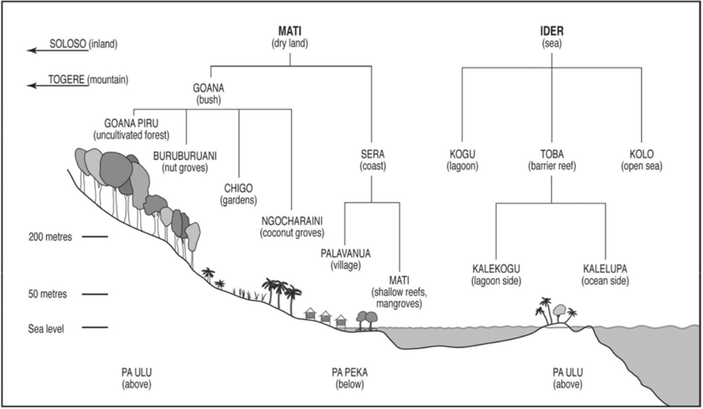

**Figure 2:** Marovo coastal profile (reproduced from Hviding_1996:138 with the permission of the University of Hawai’i Press)

The next two examples are from Malaita in the Southeast Solomons. Walter Ivens writes about the salt-water people of Lau and Sa’a, two environments not unlike the Marovo one above, with both descriptions being limited to the land close to the coast that is used intensively. One is a description of the Lau people who live on artificially constructed islands in the Lau lagoon. Fishing forms the basis of their subsistence. Although the islands themselves have no cultivable land, the people have access to limited adjacent land on Malaita for their gardens. Ivens writes (1930:266):

> Land in the vicinity of the beach is called *hara*. Flat sandy land just above the beach is called *nuu*. Breadfruit and certain other fruit trees grow there. The lower foothills are known as *fafo asi* (lit. ‘above the sea’), and it is there that people have their taro gardens. Garden ground, as distinct from uncleared forest, is called *gano*; *gano alu* is old garden ground that is not yet ready for planting, ground … that has not yet been rested sufficiently. Virgin forest is *kʷaena*.

Ivens’ second example is that of Sa’a, and its close neighbour, Ulawa, in the south-east of Malaita. The two share an almost identical language. Ivens writes (1927 [reissued 1972]:357–358):

> The sandy soil just above the beach is called *uluone* [*ulu* ‘head’ + *one* ‘sand’], and on this soil the coconuts grow best … At the back of this tract of sandy soil is the *pwainaa*, subject to flooding and with a black soil … The fruit trees abound in this tract. Ulawa calls the upper part of this by the name *akohu*; it is less wet in character. The land rises immediately behind the *pwainaa* … to the next district, *pwaʔu*. The meaning of this word is ‘smoke’ … At Sa’a, the upper division of *pwaʔu* is called *lapwa*, from the undergrowth there of the fern of the same name. The land up higher still is called in Sa’a *ano mola* [‘earth’ + ‘only’, i.e. earth with no rocks or stones], and in Ulawa *kalona* … Another term applied to the sandy soil of the old beaches is *ʔoʔu*. In some places the land immediately under the first ridge of upheaved coral rocks is called *ote*; the trees in the *ote* grow to a very large size, especially the teak, *nau*, and the *awa*, Nephelium pinnatum. The *ote* ground is generally wet owing to soakage from the hills.

Our last example is of the small high island of Tikopia, as described by Raymond Firth in his volume *We, the Tikopia* (1957). Tikopia is one of the Polynesian outliers, lying northeast of the Banks and Torres Islands, Vanuatu. In form it is a small, compact oval roughly four kilometres by three, and at the time of Firth’s fieldwork in 1928–29 it supported a population of just under 1300. It is likely that every surface feature of any significance would be known in detail. Firth provides two maps, reproduced here as Map 8(a), showing topographical features, and Map 8(b), which shows settlement features such as villages, springs and tracks.

From Map 8(a) we can see that the mountains in the north of the island are simply *Mauŋa*, ‘mountain’, with the bulk of the tallest, Reani, labelled *Mauŋa Lasi* (‘great mountain’). The crest itself is termed *Te Uru o te Fenua* (‘the head of the land’) (p.27). The large lake in the centre of the island, a former crater lake and not a lagoon, is simply *Te Roto* (literally ‘middle, interior’), or more familiarly *Te Vai* (‘fresh water’) (p.23). Firth explains that the water is fresh because the apparent channel linking the lake to the sea is normally silted up, but may be dug out at certain seasons of the year when the lake is full from rain and the tide is high, to allow excess lake waters to flow down to the sea (p.25). The sand bar separating the lake from the sea on its eastern side is *Te Koro* (‘barrier of sand or stone against the sea’). Two rocky pinnacles which are all that remain of the former eastern wall of the crater, are *Foŋa te Koro* (‘top of the Koro’) and *Foŋa Nuku* (‘top of the settlement’). Breaks in the reef which enable canoes to pass to the open ocean are simply *Te Ava* (‘channels in the reef’). A large rock off the west coast is *Fatu roa* (‘tall rock’), while two small rocky outcrops in the east are *Rua motu* (‘two islets’). Sometimes included in place names are modifying terms like *tua* ‘back’, *tafa* ‘side’, *foŋa* ‘top, crown’ and *muri* ‘behind’. There are a number of springs named in both maps. These are referred to as *Vai* followed by a diferentiating name. The swampy area to the south is *Te Ropera*, a word whose etymology, Firth suggests (p.332) is *roto pela* [or *pera*], literally ‘middle mud’. Along the northern coast are cliffs, *mato*, (p.27) and caves or rock shelters, *ana* (p.23) (these last not shown on the map).

On Map 8(b) are names which loosely denote localities or districts, treated by Firth as proper names. For *Ravenga* and *Faea*, the two major divisions of the island, we can offer no explanation. But for three others, *Namo*, the point at which the lake exits to the sea, *Uta* at the western edge of the lake, and *Tai*, the flat plain of alluvial soil in the south which is largely taken up by swamp, we can posit POc origins based on their physical nature (*namo ‘lagoon; enclosed water’, *qutan ‘bushland, hinterland’, *tasik ‘sea, salt water’).

In his discussion of land tenure (p.332), Firth refers to the *tofi*, areas of mixed woodland and clearing of varying size for which he adopts the translation ‘orchard’. Then there are the *vao*, open stretches of ground which are planted in taro, which he refers to as ‘gardens’. Paths, *ara*, run through orchards and gardens.

Although these examples include many terms for which we can find no cognates, the features they label have much in common. They represent the places where most of the daily activities of their inhabitants are centred, from the forested areas where they hunt, to garden land in its various stages, to coastal swamp and sand, to the lagoon and reef, to islands and the open sea beyond.

A number of the nouns reconstructed in this chapter and the next functioned as both common nouns and as local nouns, as their modern reflexes continue to do. For example, *qutan as a common noun denoted the bush or bushland, while its local-noun use in the prepositional phrase *i qutan could have either the expected sense ‘in the bush’ or the directional sense ‘(up) inland’. For further discussion and reconstruction of local-noun senses, see Chapter 8, §2.

The rest of this chapter is organised under the following headings: land mass, coastal features, inland topographical features, land defined by vegetation, inland water features, mineral substances, fire, and destructive natural events. Details of seascape will be dealt with in Chapter 4.

## 2. Land mass

### 2.1. Land, mainland

Reflexes of both POc *panua (vol.1,62) and *tanoq[^2] are widely used to refer to the extent or physical state (rocky, flat, dry etc.) of the land, and may also be used to contrast land with sea. The two reconstructions, however, differed in their broader meanings. POc *panua had several senses, outlined below, while POc *tanoq referred particularly to ground or soil. Large islands, the major land masses of a region, are often denoted by reflexes of *panua, and this term appears in proper names for major islands, e.g. *Hanua To’o* ‘San Cristobal’ (lit. ‘solid land’), as used in Arosi, of the Southeast Solomons, *Vanua Levu* and *Vanua Balavu* (lit. ‘big land’ and ‘long land’) in Fijian. Note also the Tongan form *fonua lahi* (lit. ‘big land’) for ‘mainland’. In ’Are’are, the land–sea contrast is expressed in *riu i hanua* ‘travel overland’ and *riu i āsi* ‘travel by sea’. In Arosi, the land is either *henua hū* or *ano hū* (*hū* ‘dry’) while the sea *is asi*. In nearby Sa’a the contrast is between *ano hū* ‘dry land’ and *esi* ‘sea’.

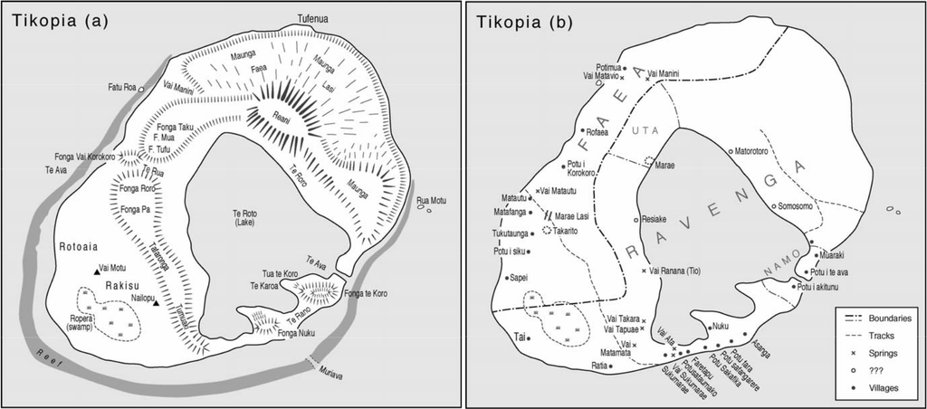

**Map 8:** Tikopia (after Firth_1936:xxii)

| **PMP** |  | *banua | ‘inhabited territory, where a community’s gardens, houses and other possessions are’ (Blust 1987) |
| --- | --- | --- | --- |
| **POc** |  | *panua | (1) ‘inhabited area or territory’; (2) ‘community together with its land and things on it’; (3) ‘land, not sea’; (4) ‘(with reference to weather and the day/night cycle) the visible world, land and sk… |
| Adm | Mussau | *anua* | ‘land’ |
| Adm | Penchal | *panu* | ‘village’ |
| NNG | Gedaged | *panu* | ‘village, settlement, hamlet’ |
| NNG | Manam | *anua* | ‘village’ |
| NNG | Tami | *panu* | ‘house’ |
| PT | Motu | *hanua* | ‘village, town’ |
| PT | Molima | *vanua* | ‘house’ |
| PT | Kilivila | *valu* | ‘land; any open space which may be inhabited’ |
| MM | Vitu | *vanua* | ‘garden’ |
| MM | Tabar | *vanua* | ‘house’ |
| MM | Taiof | *fan* | ‘village’ |
| SES | Bugotu | *vanua* | ‘land, island’ |
| SES | Lau | *fanua* | ‘land, the earth, world; weather’ |
| SES | ’Are’are | *hanua* | ‘land, country, village place, country; the area where a person lives, where his possessions are’ |
| NCV | Mota | *vanua* | ‘land, island, village, place’ |
| SV | Lenakel | *na-uanu* | ‘village’ |
| SV | Anejom̃ | *in-henou* | ‘taro swamp’ |
| NCal | Nemi | *bʷan(guc)* | ‘soil’ (*guc* ‘earth’) |
| Mic | Woleaian | *farɨw* | ‘land, island’ |
| Fij | Rotuman | *hanua* | ‘land, country, place; native land or place, home’ |
| Fij | Bauan | *vanua* | ‘land (not sea), territory, region, place, community, country; (in expressions for weather) the visible world, land, sea and sky’ |
| Pn | Tongan | *fonua* | ‘land, country, territory, place; people (of the land)’ |
| Pn | Samoan | *fanua* | ‘land; afterbirth’ |
| Pn | Tahitian | *fenua* | ‘land’ |
| Pn | Hawaiian | *honua* | ‘land, earth’ |

cf. also: Examples of phrasal expressions containing reflexes of *panua

| PT | Kilivila | *vilouwokuva valu* | ‘uninhabited land’ |
| --- | --- | --- | --- |
| PT | Kilivila | *kabinai valu* | ‘good garden land’ |
| SES | Sa’a | *henue hū* | ‘solid land, dry land, heritage’ |
| SES | Sa’a | *tolona henue* | ‘hill country’ |
| Fij | Wayan | *udu ni vanua* | ‘headland’ |
| Fij | Bauan | *vanua liwa* | ‘land far away from settlements’ |
| Pn | Anutan | *puŋa penua* | ‘summit; highest point of an island’ |
| Pn | Tongan | *fonua lahi* | ‘mainland’ |

cf. also: Other examples refer to more planetary aspects, such as the day/night cycle and weather

| NNG | Manam | *anua izara* | ‘dawn’ |
| --- | --- | --- | --- |
| NNG | Manam | *anua idaradara* | ‘evening glow’ |
| PT | Motu | *hanua boi* | ‘night’ |
| SES | Lau | *fanua gʷari* | ‘cold weather’ |
| SES | Lau | *fanua sato* | ‘sunny weather’ |
| Fij | Bauan | *boŋi na vanua* | ‘become night’ (lit. ‘land is nighted’) |
| Fij | Bauan | *siŋa na vanua* | ‘become daylight’ (lit. ‘land is sunned’) |
| Pn | Rennellese | *henua pō* | ‘night time’ |

POc *tanoq ‘earth, ground, soil; land’ has already been reconstructed in vol.1,119, as a term relevant to horticulture. As a common noun its denotations ranged from the soil beneath one’s feet to the total land mass on which one lived. Besides its use as a common noun, it was also used as a local noun with meanings like ‘down on the ground, down below’ (Ch.8, §2.2.5).

| **PMP** |  | *taneq | ‘earth, land’ (Dempwolff 1938) |
| --- | --- | --- | --- |
| **POc** |  | *tanoq | ‘earth, ground, soil; land’ |
| Adm | Loniu | *(ko)tan* | ‘earth’ |
| Adm | Lou | *tan* | ‘loose soil’ |
| NNG | Gedaged | *tan* | ‘soil, ground, land, garden, earth, world’ |
| NNG | Takia | *tan* | ‘ground, earth, land’ |
| NNG | Kove | *tano* | ‘earth, sand’ |
| NNG | Kove | *tano(pu)* | ‘mainland (of New Britain)’ (*pu* ‘base, basis’) |
| PT | Motu | *tano* | ‘earth, soil, country, land’ |
| PT | Minaveha | *tano* | ‘dirt’ (*tanopi* ‘earth, ground, world’) |
| SES | Bugotu | *tano* | ‘earth, ground’ |
| SES | Sa’a | *ano* | ‘ground, garden ground’ |
| SES | Arosi | *ano* | ‘ground, earth, soil, the land’ |
| NCV | Raga | *tano* | ‘earth’ |
| NCV | Lewo | *tano* | ‘earth, land’ |
| SV | Kwamera | *təna* | ‘earth, ground; land, island, country’ |
| NCal | Iaai | *kɔnɔ* | ‘earth, ground’ |
| Mic | Kiribatese | *tano* | ‘earth, ground, soil’ |
| Mic | Woleaian | *tar* | ‘earth, ground, soil’ |

cf. also: Certain conventional phrases, such as the following, indicate the semantic range of reflexes of *tanoq

| NNG | Gedaged | *tan wululu* | ‘fine soil’ |
| --- | --- | --- | --- |
| NNG | Gedaged | *tan fufulek* | ‘planet earth’ |
| PT | Minaveha | *tano bigana* | ‘fertile land’ |
| PT | Motu | *tanobada* | ‘land as distinguished from sky and sea’ (lit. ‘big land’) |
| SES | Sa’a | *ano hū* | ‘land as opposed to sea’ |
| SES | Arosi | *ano sada* | ‘flat country’ |
| SES | Arosi | *ano mamata* | ‘land as opposed to sea’ (lit. ‘dry land’) |

The term *tanoq disappears in Fiji and Polynesia, where the concept of ‘earth, soil’ is denoted by reflexes of PCP *gʷele, PPn *kele (see §7.6).

### 2.2. Island

Two POc terms are glossed ‘island’. These were probably reserved for small islands. Of our reconstructions, it seems that *nusa was a common noun in POc, but Southeast Solomonic, Fijian and Polynesian reflexes seem to reflect *qa-nusa, with the local adverb formative *qa- (Ch.8, §2.1). The expected meaning of *qa-nusa is something like ‘at our own island’, and this is in accord with the use of its reflexes in placenames. The Micronesian reflexes, however, suggest that the prefixed form has also come to be used as a common noun.

| **PMP** |  | *nusa | ‘island’ (Dempwolff 1938) |
| --- | --- | --- | --- |
| **POc** |  | *nusa | ‘island’ |
| **POc** |  | *qa-nusa | ‘at our own island’ |
| NNG | Bariai | *(i)nu* | ‘island’ (< POc *i nusa ‘at (our) island’) |
| NNG | Takia | *nui* | ‘island, reef’ |
| NNG | Gedaged | *nui* | ‘island’ |
| PT | Gapapaiwa | *nua* | ‘island’ |
| PT | Dobu | *nua* | ‘coral reef, coral patch’ |
| MM | Nduke | *nusa* | ‘island’ |
| MM | Roviana | *nusa* | ‘island’ |
| SES | Arosi | *(a)nuta* | ‘the name of a small island’ |
| SES | Arosi | *nu-nuta* | ‘island’ |
| SES | Lau | *(a)nuta* | ‘island (only in names)’ |
| NCal | Xârâcùù | *nɨi* | ‘island’ |
| Mic | Satawalese | *(a)lɨt* | ‘small island’ |
| Mic | Woleaian | *(ya)rɨta* | ‘small uninhabited island’ |
| Fij | Bauan | *(a)nuða* | ‘element in place names of small offshore islands’ |

Anuta, the name of a very small Polynesian island near Tikopia, is probably also cognate.

The primary role of *motus in POc appears to have been as a stative verb, ‘be broken off, severed’ (see vol.1,247 for likely derivation from PMP *utus ‘break under tension’). *motus may have been applied only to islets, isolated rocks and detached reefs, and not to larger islands more suitable for habitation.

| **POc** |  | *motus | [N] ‘island, detached reef’; ‘(V) become, be broken off, severed’ (vol. 1, p.247) |
| --- | --- | --- | --- |
| NNG | Bing | *mōt* | ‘island’ |
| NNG | Manam | *motu* | ‘island’ |
| NNG | Yabem | *meʔ* | ‘reef’ |
| NNG | Numbami | *motu* | ‘reef’ |
| PT | Motu | *motu-motu* | ‘island; detached portion of reef’ (*motu* ‘to break, as a string’) |
| PT | Hula | *mou* | ‘island’ |
| SES | Sa’a | *mou* | ‘be broken off’ (*malau mou* ‘an islet’, *hau mou* ‘an isolated rock’) |
| NCV | Mota | *(vanua)mʷot* | ‘island’ (lit. ‘land broken off’) |
| SV | Lenakel | *(tən)murh* | ‘island’ (tən ‘earth, land’) |
| Fij | Rotuman | *mofu* | ‘rock (in the sea)’ |
| Fij | Bauan | *motu, (ya)motu* | ‘small detached reef’ |
| Pn | Niuean | *motu* | ‘island’ |
| Pn | Tongan | *motu* | ‘island; break, become separated’ |
| Pn | Rennellese | *motu* | ‘to break, sever’ |
| Pn | Rennellese | *motu hatu* | ‘reef rock island’ (*hatu* ‘rock’) |
| Pn | Samoan | *motu* | ‘island; severed’ |
| Pn | Tahitian | *motu* | ‘islet; be cut, severed’ |
| Pn | Māori | *motu* | ‘island’ |
| Pn | Hawaiian | *moku* | ‘island; sever, cut’ |

Cognates of PWOc *(s,t)imuR (below) may reflect POc *timu(R) ‘wind bringing light rain’ (from PMP *timuR ‘south or east wind’) (cf. Ch. 5, §4.2). Waruno Mahdi suggests (pers. comm.) that there has been semantic drift from wind to cloud to cloud over island, a traditional navigator’s way of locating islands. Alternatively, there may be an unrelated word, at least in PWOc:

| **PWOc** |  | *(s,t)imuR | ‘island’ |
| --- | --- | --- | --- |
| PT | Muyuw | *sim, simulan* |  |
| PT | Iduna | *himula* |  |
| PT | Dobu | *simula* |  |
| PT | Kilivila | *simla* |  |
| MM | Sursurunga | *sim* |  |

Although the next reconstructed form is traceable back to PMP as a verb, its use as a noun is a later development, with its application to a chain of islands apparent only in the Central Pacific.

| **PMP** |  | *qatuR | [V] ‘pave with stones; pile or stack up, arrange, order, put in sequence’ (ACD) |
| --- | --- | --- | --- |
| **POc** |  | *qatu(R) | [N] ‘number of things in a line, row’ |
| SV | Anejom̃ | *n-at(hat)* | ‘line of stones’ (inhat ‘stone’) |
| **PCP** |  | *qatu | ‘number of things in a line, row, as a chain of islands’ |
| Fij | Rotuman | *afu* | ‘number of things in a line, row’ |
| Fij | Wayan | *atu* | ‘first element in name of island chain, e.g. *atu Yasawa*’ |
| Fij | Bauan | *yatu* | ‘first element in name of island chain’ (e.g. *Yatu Lau* ‘the Lau islands’) |
| Pn | Tongan | *ʔotu* | ‘row, line, series, chain or long group (e.g. of islands)’ |
| Pn | Niuean | *atu* | ‘row of things, group’ |
| Pn | Niuean | *atu motu* | ‘group of islands’ |
| Pn | Rennellese | *ʔatu* | [N] ‘generation; row, column, group, as of islands, stones, posts, people’; [V] ‘be of the same generation’ |
| Pn | Samoan | *atu* | ‘row (as of chairs); range (as of hills); chain (as of lakes); set, row (as of teeth)’ |
| Pn | Samoan | *atu motu* | ‘group of islands, archipelago’ |
| Pn | Nanumean | *atu* | ‘group or chain of islands’ (*atu fenua elise* ‘the whole Ellice group’, *atu paipai* ‘the whole world’) |

## 3. Coastal features

This section treats named features of the coastal landscape other than shore reefs and tides, which are dealt with in the next chapter.

### 3.1. Beach, shore

Two POc reconstructions can be made for ‘beach’. One, *qone, seems primarily to have meant ‘sand’, but the sense ‘sandy beach’ is also quite widely reflected (see §7.5). The other reconstruction, *biker, is less firmly based. However, it is possible that the terms from Huon Gulf languages listed below may also be reflexes. If they are, then the reconstruction should be *bʷiker.

| **POc** |  | *(b,bʷ)iker | ‘beach, esp. sandy beach’ |
| --- | --- | --- | --- |
| MM | Bali | *bikere* | ‘beach’ |
| MM | Bulu | *bike* | ‘beach’ |
| SV | Kwamera | *nə-pəkər* | ‘sand, sandy beach’ |
| Mic | Kiribatese | *bike* | ‘beach, sand, sand bank, sandy soil’ |
| Mic | Mortlockese | *ppɛ* | ‘beach, sand’ |
| Mic | Puluwatese | *ppi* | ‘sand, sand beach, sand spit’ |
| Mic | Ponapean | *pīk* | ‘sand’ |
| Mic | Ponapean | *pika-pik* | ‘sandy’ |
| Mic | Woleaian | *pix(a)* | ‘small island, islet’ |

cf. also: the following Huon Gulf terms:

| NNG | Adzera | *ŋiʔ* | ‘salt’ |
| --- | --- | --- | --- |
| NNG | Dangal | *ᵑgik* | ‘salt’ |
| NNG | Yabem | *gʷeʔ* | ‘sea’ |
| NNG | Kaiwa | *gielk* | ‘sea’ |
| NNG | Hote (Misim) | *ɣek* | ‘sea’ |
| NNG | Vehes | *ɣek* | ‘sea’ |
| NNG | Patep | *ɣek* | ‘sea’ |

The reflexes of POc *nuku are semantically diverse, ranging from ‘sand’, ‘sandbar at river mouth’, ‘island’, and ‘settlement’ to ‘land, country’. However, the agreement between the Southeast Solomonic languages and Bauan Fijian indicates that POc *nuku referred to sandy ground. It may have been used figuratively for land or settlement, especially in place names, bearing in mind that settlements are often located on flat sandy ground just above the beach.

| **POc** |  | *nuku | ‘sandy ground, sand bank, sand spit’ |
| --- | --- | --- | --- |
| NNG | Kove | *nū* | ‘small offshore island’ |
| MM | Vaghua | *nəɣə* | ‘island’ |
| MM | Varisi | *nuɣu* | ‘island’ |
| MM | Babatana | *nu-nu* | ‘island’ |
| SES | Gela | *nuɣu* | (i) ‘a flat and sandy place near the beach’; (ii) ‘a reef far out at sea, larger than sembe mbuto’ |
| SES | Gela | *nu-nuɣu* | (i) ‘quicksand’; (ii) ‘a river bar’ |
| SES | Gela | *(mu)nuɣu* | ‘sand bar at river mouth; island in river’ |
| SES | Lau | *nū* | (i) ‘flat ground near the shore’; (ii) ‘coral reef where it juts out, seaward part of reef’; ‘flat sandy land just above the beach’ |
| SES | Kwaio | *nuʔu* | ‘margins of sand, area of strand immediately above the beach’ |
| SES | Arosi | *nu-nuʔu* | ‘sand on the beach, sandy soil’ |
| SES | Arosi | *(mara)nuʔu* | ‘a river flat, plain made by river, sandy level ground near the shore’ |
| Fij | Bauan | *nuku* | ‘sand’ (nuku-nuku ‘sandy’) |
| Fij | Bauan | *uðu ni nuku* | ‘sandbank jutting out into the sea’ (*uðu* ‘nose’) |
| Pn | Niuean | *nuku* | ‘land, country, place’ (obsolete) |
| Pn | Tongan | *nuku* | ‘element in place names’ |
| Pn | Rennellese | *nuku* | ‘legendary isles or settlements of the gods; a part of place names’ |
| Pn | Samoan | *nuʔu* | ‘village, home’ (*nuʔutūloto* ‘islet’) |
| Pn | Tikopia | *nuku* | ‘dwelling, settlement, island where settlement situated. Used in many Tikopia house names’ |
| Pn | Marquesan | *nuku-* | ‘first element in many place names’ |
| Pn | Tahitian | *nuʔu* | ‘earth, land (only as part of place names)’ |
| Pn | Tuamotuan | *nuku* | ‘earth, land’ |
| Pn | Māori | *nuku* | ‘the earth, generally personified; wide extent of the land, fenua’ |

Coastlines, particularly island coastlines, may be characterised as ‘windward coast’ or ‘leeward coast’ in latitudes where tradewinds blow for most of the year. Marovo (MM), for instance, has parallel terms for the ocean-facing side of a barrier island, *kale-lupa* (*kale* ‘side’, *lupa* ‘the beaches, reefs and seascape on the outer or windward side of the barrier reef’) and the lagoon-facing side, *kale-kogu* (*kogu* ‘lagoon’). Roviana (MM) refers to the ocean side of an island as *vuragarena*, which Waterhouse (1949) contrasts with *tutupeka*. Kia (MM) adapts body part terms for ‘back’ and ‘belly’, *taguru-mo* ‘windward side of island’ and *tia-mo* ‘leeward side of island’. Sa’a (SES) has *asi matawa* ‘weather shore’ and *asi mae* ‘lee shore’.

In Chapter 4 we have reconstructed PEOc *tasik maquri(p) ‘open sea; ocean on the weather side; weather shore’ (literally ‘live sea’) and PEOc *tasi mate ‘sheltered sea, lee shore’ (literally ‘dead sea’), terms which, from their reflexes, may apply both to the sea or to the affected coastline.

The reconstruction below, PEOc *liku, is glossed ‘windward side’, but it seems likely that its reflexes are members of a larger set reflecting PMP *likuD, POc *liku(r) ‘person’s back’ whose reflexes are used in a number of languages with the senses ‘back of s.t.’, ‘outside’ (Ch.8, §2.3.5). The use of reflexes of this term for ‘windward side’ reflects the fact that the outside of a barrier reef is its windward side.

| **PEOc** |  | *liku | ‘windward side’ |
| --- | --- | --- | --- |
| Mic | Marshallese | *liki* | ‘ocean side of; outside’ |
| Mic | Kiribatese | *(āi)niku* | ‘ocean side of coral islands’ |
| Fij | Wayan | *liku* | ‘windward side’ |
| Pn | Niuatoputapu | *liku* | ‘windward side’ |

Similarly, terms located for the leeward or sheltered side include reflexes of an apparently more general term, PMP *duŋduŋ, POc *ruru.

| **PMP** |  | *duŋduŋ | ‘sheltered as from wind, rain or sun’ (ACD) |
| --- | --- | --- | --- |
| **POc** |  | *ruru | ‘calm, sheltered’ |
| Fij | Bauan | *rūrū* | ‘calm’ |
| Pn | Rennellese | *gugu* | ‘be calm, sheltered, to leeward’ |
| Pn | Hawaiian | *lulu* | ‘calm area leeward of an island’ |

References to ‘shore’ occur also in locative expressions (see Chapter 8). To a person at sea, reflexes of POc *qutan will refer to the shore, while to a person inland, reflexes of *laur can carry the same interpretation.

### 3.2. Bay

The gloss of our next reconstruction, POc *tobʷa is soundly based for PEOc, but depends for promotion to POc on reinterpretation of the name given to the barrier reef islands which enclose Marovo Lagoon. POc *tobʷa is also the reconstructed form for ‘belly, stomach, bag’ and it is possible that ‘bay’ is a metaphorical extension of the term.

| **POc** |  | *tobʷa | ‘bay, harbour; belly, stomach’ |
| --- | --- | --- | --- |
| Adm | Tench | *tova* | ‘belly’ |
| MM | Marovo | *toba* | ‘elevated barrier reefs’ (i.e. islands enclosing sheltered water) |
| MM | Roviana | *toba* | ‘name of barrier island’ |
| **PEOc** |  | *tobʷa | ‘bay’ |
| SES | Tolo | *tobana* | ‘abdomen, belly’ |
| SES | Sa’a | *apʷa-apʷa* | ‘bay, indentation in coast’ |
| SES | Arosi | *obʷa-obʷa* | ‘bay, harbour’ |
| NCV | Mota | *toqa(i)* | ‘belly’ |
| Fij | Bauan | *toba* | ‘bay or gulf’ |

The next set has specific reference to ‘bay’ only in Polynesia. As a POc term, it is a verb used descriptively.

| **POc** |  | *paŋa | ‘be open, gape’ |
| --- | --- | --- | --- |
| PT | Motu | *haga* | [ADJ] ‘open’ |
| MM | Tolai | *paŋaŋa* | ‘be open, yawn, gape’ |
| SES | Lau | *(a)faŋa* | ‘open wide, gape’ |
| SES | Tolo | *(o)vana* | ‘opening’ |
| NCV | Mota | *waŋa* | ‘gape’ |
| **PPn** |  | *faŋa | ‘bay’ |
| Pn | Tongan | *faŋa* | ‘small or private beach’ |
| Pn | Samoan | *faŋa* | ‘bay’ (*matā-faŋa* ‘beach, shore’) |
| Pn | Tahitian | *faʔa* | ‘valley, low place among the hills’ |
| Pn | Māori | *ɸaŋa* | ‘bay, harbour, estuary’ |
| Pn | Hawaiian | *hana* | ‘bay, valley (in place names)’ |

### 3.3. River mouth

Polynesian languages use a compound for the mouth of a river, with elements derived from POc forms *muri ‘behind’ + *waiR ‘river, fresh water’.

| **PPn** |  | *muri-wai | ‘mouth of river’ |
| --- | --- | --- | --- |
| Pn | Tongan | *mui-vai* | ‘mouth of river’ |
| Pn | Samoan | *muli-vai* | ‘mouth of river’ |
| Pn | East Futunan | *muli-vai* | ‘mouth of river’ |
| Pn | Māori | *muri-wai* | ‘backwater, lagoon at mouth of river’ |
| Pn | Hawaiian | *muli-wai* | ‘mouth of river; pool near river mouth (as behind sandbar)’ |

No POc reconstruction is available for ‘river mouth’. This concept was probably named by a compound connecting ‘river’ or ‘fresh water’ with a body part. The most widespread label is ‘leg’ or more likely, ‘foot of river’, and this may well reflect a POc collocation. We find:

| NNG | Mapos Buang | *bel vaɣa* | ‘mouth of river’ (*bel* ‘water’, *vaɣa* ‘leg/foot’) |
| --- | --- | --- | --- |
| NNG | Takia | *you ŋe-n* | ‘mouth of river’ (*you* ‘water’, *ŋe-* ‘leg/foot’) |
| PT | Iduna | *gufa wa-ʔage* | ‘mouth of river’ (*gufa* ‘river’, *ʔage-* ‘leg/foot’) |
| PT | Molima | *goʔila ae(na)* | ‘mouth of river’ (*goʔila* ‘fresh water’, *ae* ‘leg/foot’) |
| SES | Lau | *ʔae-na kafo* | ‘mouth of river’ (*ʔae-* ‘foot/leg’, *kafo* ‘water’) |

### 3.4. Cape, prominent land

POc terms that can be glossed ‘cape, headland’ are all words for a body part or part of an object conceived of as similar in shape. The first is *(i,u)cuŋ ‘nose’. It seems likely that PCP *uju, which refers to ‘projecting or exposed land’ also reflects POc *ucuŋ ‘nose’.

The suffixed *-a* of PPn *utu-a below reflects the POc locative nominalising suffix *-an (vol.1,33–34).

| **PMP** |  | *ijuŋ, *ujuŋ | ‘nose’ (ACD) |
| --- | --- | --- | --- |
| **POc** |  | *(i,u)cuŋ | ‘nose; cape’[^3] |
| NNG | Bing | *uyu* | ‘headland, point, nose’ |
| PT | Motu | *idu(ka)* | ‘headland’ |
| MM | Nakanai | *(ma)isu* | ‘nose; cape’ |
| MM | Tinputz | *ihun* | ‘nose; cape, point’ |
| SES | Gela | *ihu* | ‘nose; cape’ |
| Fij | Bauan | *uðu* | ‘nose; cape, mountain peak’ |
| Pn | Rapanui | *ihu* | ‘nose; headland, point’ |
| **PCP** |  | *uju | [V] ‘project’ |
| **PPn** |  | *utu-a | ‘projecting land’ |
| Fij | Wayan | *udu* | ‘stick out, project’ |
| Fij | Wayan | *udu ni vanua* | ‘headland’ |
| Pn | Tongan | *utua* | ‘be conspicuous’ |
| Pn | East Uvean | *utua* | ‘point, promontory’ |
| Pn | Rennellese | *utua* | ‘point, cape’ |
| Pn | Kapingamarangi | *utua* | ‘projecting point in reef’ |
| Pn | Tuvalu | *utua* | ‘that part of shore visible at low tide’ |
| Pn | Takuu | *utua* | ‘land normally under sea but exposed by low tide’ |
| Pn | Tokelauan | *utua* | ‘shelving reef’ |

The last four Pn reflexes restrict the sense to a part of reef exposed at low tide, but retain the sense of projection/prominence.

Reflexes of the next item, POc *ŋoro-ŋorok with the gloss ‘cape’ are few and are not well distributed, but more careful inspection of the data reveals that these reflexes belong to the same cognate set as another word for ‘nose’. We give the reflexes in two sets: those with the gloss ‘cape’ or ‘headland’ first and then those for ‘nose’. Alone, the first set suggests a reconstruction *ŋora-ŋora, but comparision with the terms glossed ‘nose’ reveals that final *-a* is simply the reflex that occurs in certain Southeast Solomonic languages. POc *ŋoro-ŋorok ‘nose, cape’ in its turn was originally probably a colloquial word for ‘nose’ derived from POc *ŋorok ‘snore’.

| **POc** |  | *ŋoro-ŋorok | ‘cape’ |
| --- | --- | --- | --- |
| MM | Sursurunga | *ŋor-ŋor* | ‘headland, point of land jutting out into the sea’ |
| SES | Longgu | *ñora-ñora* | ‘headland, point’ |
| SES | Lau | *ŋo-ŋora* | ‘nose; point, headland, cape’ |
| SES | Sa’a | *ŋora-ŋora* | ‘cape’ |
| SES | Arosi | *ŋora-ŋora* | ‘cape, isthmus’ |

| **POc** |  | *ŋoro-ŋorok | ‘nose’ |
| --- | --- | --- | --- |
| NNG | Sio | *i-ŋo-ŋoro* |  |
| NNG | Amara | *(s)ŋorek(a)* |  |
| NNG | Kairiru | *ŋaRi(-)* |  |
| MM | Notsi | *ŋul-ŋul* |  |
| MM | Madak | *ŋo-ŋo* | ‘nasal mucus’ |
| MM | Tangga | *ŋoro-ŋoro* |  |
| MM | Patpatar | *ŋar-ŋaro* |  |
| MM | Ramoaaina | *ŋir-ŋiro* |  |
| MM | Selau | *ŋor-ŋoro* |  |
| MM | Varisi | *i-ŋoro* |  |
| MM | Ririo | *ni-ŋir* |  |
| SES | Lau | *ŋo-ŋora-* |  |
| SES | N Malaitan | *ŋo-ŋoro-* |  |

The final reconstruction, PEOc *mata ‘point of land, headland’ is evidently an extension of the more basic meanings attributed to POc *(m,mʷ)ata, namely ‘point, blade, cutting-edge (of a weapon or instrument)’ (vol.1,89).

| **PEOc** |  | *mata | ‘point of land, headland’ |
| --- | --- | --- | --- |
| NCal | Nyelâyu | *mā(lã pʰwēmʷa)* | ‘point of the mainland (= south)’ |
| NCal | Nêlêmwâ | *mā(wamʷa)* | ‘point of the mainland (= south)’ |
| **PPn** |  | *mata | ‘point of land, headland; point, blade, cutting-edge (of a weapon or instrument)’ (Biggs and Clark 1993) |
| Pn | Niuean | *mata* | ‘a point of land’ |
| Pn | East Futunan | *mata* | ‘point of land, cape’ |
| Pn | Rennellese | *mata henua* | ‘western end of Rennell Island’ |
| Pn | Māori | *mata* | ‘point of land, headland’ |
| Pn | Tuamotuan | *mata* | ‘point of land, headland’ |

## 4. Inland topographical features

### 4.1. Hill, mountain

Even quite small islands can be dominated by high peaks. While a number of peaks in New Britain and New Ireland reach 2000m, the much smaller islands of Manam and Karkar have peaks of 1800m, and Goodenough Island in the d’Entrecasteaux group has one of 2500m. Of the reconstructions below, POc *koro[^4] and POc *solos have meanings centred on mountain or mountainous country. POc *puŋa-puŋa may have also denoted ‘mountain’ but its reflexes in Pn have come to refer to ‘upper surface’. Of the other reconstructions, *buku and *pwotu referred rather to a protuberance or a bulge-shaped object.

| **POc** |  | *koro | ‘mountain, hill’ |
| --- | --- | --- | --- |
| NNG | Manam | *oro* | ‘go landwards (away from the sea)’ |
| NNG | Lamogai | *oro* | ‘mountain’ |
| NNG | Sissano | *ol* | ‘mountain’ |
| PT | Motu | *oro-ro* | ‘mountain’ |
| PT | Balawaia | *ɣolo* | ‘mountain’ |
| PT | Kilivila | *koya* | ‘mountain’ |
| MM | Mono-Alu | *olo* | ‘hill’ |
| SES | Gela | *ɣoro* | ‘back country, forest-covered interior hills’ |
| SES | Lengo | *ɣo-ɣoro* | ‘mountain’ |
| SES | Arosi | *oro* | ‘high’ |
| Mic | Kosraean | *ɔl* | ‘mountain’ |
| Fij | Bauan | *koro* | (i) ‘an eminence’; (ii) ‘fortified village’ |
| Pn | Rennellese | *ogo* | ‘mountain, hill, slope’ (loss of initial k- irreg.) |
| Pn | Tikopia | *koro* | (i) ‘fort’; (ii) ‘barrier of sand or stone against sea’ |
| Pn | Hawaiian | *olo* | ‘hill’ (obsolete now except in place names) |

| **POc** |  | *solos | ‘inland mountain country, highlands interior’ |
| --- | --- | --- | --- |
| MM | Kia | *soloso* | ‘mountainous interior, bush’ |
| MM | Marovo | *soloso* | ‘remote interior of large islands; the world’ |
| MM | Roviana | *soloso* | ‘inland, away from the beach’ |
| SES | Tolo | *solo* | ‘isolated areas in the middle of the island (Guadalcanal), the middle of the bush’ |
| SES | Lau | *tolo* | ‘mountain, hill country, interior of island; land’ |
| SES | Kwaio | *tolo* | ‘mountains, mountainous’ |
| SES | Sa’a | *tolo* | ‘hill’ |
| SES | Arosi | *toro* | ‘a hill (rare use); the interior, inland country of the hills’ |
| Mic | Marshallese | *tɔḷʷ* | ‘mountain’ |
| Mic | Ponapean | *tōl* | ‘small mountain’ |
| Fij | Wayan | *ðolo* | ‘highland country’ |
| Fij | Bauan | *ðolo* | ‘inland country, mountain country’ |

| **POc** |  | *puŋa-puŋa | ‘mountain’ |
| --- | --- | --- | --- |
| MM | Sursurunga | *puŋ-puŋ* | ‘mountain’ |
| SES | Ulawa | *huŋa-huŋa(ʔa)* | ‘mound, hillock’ |
| SES | Arosi | *huŋa-huŋa* | ‘hill, mountain’ |
| **PPn** |  | *fuŋa | ‘upper surface’ |
| Pn | Niuean | *fuŋa* | ‘surface, top’ (e.g. *fuŋavai* ‘surface of water’) |
| Pn | Tongan | *fuŋa* | ‘top, upper surface’ (e.g. *fuŋavaka* ‘deck of boat’) |
| Pn | Anutan | *puŋa(penua)* | ‘summit; the highest point of an island’ |

| **PMP** |  | *buku | ‘node (as in bamboo or sugarcane); joint; knuckle; knot in wood, string or rope’ (ACD; Dempwolff 1938) |
| --- | --- | --- | --- |
| **POc** |  | *buku | ‘mound, knob, joint; hill (?)’ |
| NNG | Manam | *buku* | ‘mountain; knuckle’ |
| NNG | Wogeo | *buku* | ‘knee’ |
| NNG | Mangap | *bukū-nu* | ‘knob, joint, hump’ |
| NNG | Gedaged | *buku-n* | ‘knot, on tree or cord’ |
| MM | Notsi | *buk* | ‘mountain’ |
| MM | Patpatar | *buku* | ‘knee’ |
| MM | Nakanai | *buku* | [V] ‘swell’ |
| MM | Nakanai | *bu-buku* | ‘knot in a tree’ |
| MM | Minigir | *buku-buku* | ‘elbow, knee’ |
| MM | Siar | *buk* | ‘elbow’ |
| MM | Tolai | *buk* | ‘boil, lump, corner’ |
| NCal | Nêlêmwâ | *bū-* | ‘mound, hillock’ |
| Fij | Bauan | *buku* | ‘anything knotted or humped’ |
| Pn | Tikopia | *puku-puku* | ‘rounded, blunt-headed’ |
| Pn | Hawaiian | *puʔu* | ‘any kind of protuberance, from a pimple to a hill’ |

Reflexes of *pʷotu refer consistently to ‘mountain’ only in MM languages, while some SES languages adopt the ‘knot, swelling’ meaning.

| **POc** |  | *pʷotu | ‘protuberance, bulge; mountain(?)’ |
| --- | --- | --- | --- |
| MM | Bali-Vitu | *potu* | ‘mountain’ |
| MM | Lavongai | *put* | ‘mountain’ |
| MM | Tigak | *put* | ‘mountain’ |
| MM | Kara (West) | *fut* | ‘mountain’ |
| MM | Nalik | *fut* | ‘mountain’ |
| MM | Tabar | *potu* | ‘mountain’ |
| MM | Lihir | *pot-pot* | ‘mountain’ |
| MM | Madak | *put* | ‘mountain’ |
| MM | Marovo | *botu* | ‘hill, top of hill’ |
| MM | Roviana | *botu-botu* | ‘mounds for planting yams; hillocks’ |
| SES | Gela | *pou-potu* | ‘bulge, swell’ |
| SES | Arosi | *pou-pou* | ‘round object; knot of bowstring, knot in wood’ |
| SV | Anejom̃ | *(no)pte-* | ‘node (bamboo, sugarcane)’ |

In Polynesia the typical term for mountain is a reflex of *maquŋa.

| **PPn** |  | *maquŋa | ‘mountain’ (Biggs and Clark 1993) |
| --- | --- | --- | --- |
| Pn | Niuean | *mouŋa* | ‘mountain’ |
| Pn | Rennellese | *maʔuŋa* | ‘hill, residence’ |
| Pn | Tongan | *moʔuŋa* | ‘hill, mountain’ |
| Pn | East Futunan | *maʔuŋa* | ‘mountain’ |
| Pn | Samoan | *mauŋa* | ‘hill, mountain’ |
| Pn | Tikopia | *mauŋa* | ‘hill, mountain peak’ |
| Pn | Māori | *mauŋa* | ‘mountain’ |
| Pn | Hawaiian | *mauna* | ‘mountain’ |

Note also the following PEOc reconstruction:

| **PEOc** |  | *qulu ni panua | ‘headland, mountain peak’ (POc *qulu ‘head’, ni ‘of’, *panua ‘land’) |
| --- | --- | --- | --- |
| Mic | Trukese | *wɨɾɨ-ɾ fəɾɨ* | ‘cape, point (of an island)’ |
| Fij | Bauan | *ulu ni vanua* | ‘mountain’ |

A compound term for mountain ridge (‘back’ + ‘bone’) is reconstructable for PPn:

| **PPn** |  | *tuqa-siwi | ‘mountain ridge’ (Biggs and Clark 1993) |
| --- | --- | --- | --- |
| Pn | Tongan | *tuʔa-hivi* | ‘ridge’ |
| Pn | Rennellese | *tuʔa-sivi* | ‘coastal ridge, mountain ridge; backbone’ |
| Pn | Samoan | *tua-sivi* | ‘ridge (of backbone, chain of hills etc.)’ |
| Pn | Tokelauan | *tua-hivi* | ‘ridge (of mountain, house etc)’ |
| Pn | Māori | *tua-hiwi* | ‘ridge of a hill, rising ground’ |
| Pn | Hawaiian | *kua-hiwi* | ‘mountain, high hill’ |

### 4.2. Valley

We have included two POc reconstructions glossed ‘valley’, although the second is reflected in only two languages.

| **POc** |  | *mala | ‘valley, ravine’ |
| --- | --- | --- | --- |
| Adm | Mussau | *mala(le)* | ‘valley’ |
| NNG | Takia | *mal(paon)* | ‘cliff’ |
| MM | Ramoaaina | *mala* | ‘valley, gorge, gully, ravine’ |
| MM | Tolai | *male* | ‘valley’ |
| MM | Babatana | *mala(ku)* | ‘valley’ |
| SES | Arosi | *mara(rohiana)* | ‘narrow waterless pass, ravine, valley between high hills’ (*rohi* ‘groove’) |
| SES | Arosi | *mara(wai)* | ‘river course, valley’ (*wai* ‘water, river’) |
| SES | Arosi | *mara(gohu-gohu)* | ‘slopes of a river valley’ (*gohu* ‘river flat, lower valley’) |

| **POc** |  | *salil | ‘valley’ |
| --- | --- | --- | --- |
| MM | Patpatar | *salil* | ‘valley’ |
| SES | ’Are’are | *tari* | ‘valley’ |

cf. also:

| NNG | Yabem | *saliʔ* | ‘abyss, cliff’ (possibly ‘edge of valley’) |
| --- | --- | --- | --- |

### 4.3. Cliff

We have one POc reconstruction for ‘cliff’. Two further reconstructions are at PCP and PPn level. The two last may distinguish coastal and inland cliffs.

| **POc** |  | *pʷaka(r,R) | ‘steep rocky ground, cliff’ |
| --- | --- | --- | --- |
| Adm | Lou | *pʷak* | ‘cave’ |
| NNG | Buang | *pkɛ* | ‘cliff; a steep rocky place’ |
| NNG | Bariai | *per-per* | ‘cliff’ |
| PT | Molima | *vakala* | ‘steep rocky ground, cliff’ |
| PT | Motu | *haga-haga* | ‘cliff’ (*g* for exp. *ɣ*) |
| MM | Patpatar | *par-para* | ‘cliff’ |

| **PCP** |  | *bari | ‘coastal cliff’ |
| --- | --- | --- | --- |
| Fij | Bauan | *bari (ni vatu)* | ‘(rock) cliff, precipice’ |
| **PPn** |  | *pali | ‘cliff’ |
| Pn | Rarotongan | *pari* | ‘cliff’ |
| Pn | Tahitian | *pari* | ‘cliff overhanging sea’ |
| Pn | Māori | *pari* | ‘cliff’ |
| Pn | Hawaiian | *pali* | ‘cliff’ |

| **PPn** |  | *mato | ‘precipice, steep place, cliff’ (Biggs and Clark 1993) |
| --- | --- | --- | --- |
| Pn | Tongan | *mato* | ‘precipice, cliff face’ |
| Pn | Samoan | *mato* | ‘deep narrow gorge, inland precipice’ |
| Pn | East Uvean | *mato* | ‘very steep slope’ |
| Pn | Tikopia | *mato* | ‘cliff, rock face’ |
| Pn | Rarotongan | *mato* | ‘cliff, face of a precipice’ |
| Pn | Tuamotuan | *mato* | ‘steep, precipitous, a cliff’ |
| Pn | Anutan | *mato* | ‘cliff’ |
| Pn | Tahitian | *mato* | ‘a craggy rock or precipice’ |
| Pn | Māori | *mato* | ‘deep valley’ |

### 4.4. Cave

Although terms exist in many languages for cave, we have no evidence of cognacy outside Polynesia.

| **PPn** |  | *qana | ‘cave’ |
| --- | --- | --- | --- |
| Pn | Tongan | *ʔana* | ‘cave, cavern, den’ |
| Pn | Niuean | *ana* | ‘cave, den’ |
| Pn | Samoan | *ana* | ‘cave’ |
| Pn | Rennellese | *ʔana* | ‘cave’ |
| Pn | Tikopia | *ana* | ‘cave, rock shelter’ |
| Pn | Tahitian | *ana* | ‘cave’ |

### 4.5. Flat land

Almost every language for which we have extensive lexical data has a term meaning ‘flat land’, but cognates have been difficult to find. Our only reconstruction is based on cognates from Papuan Tip and Polynesia, with Polynesia using the same term in compound form for ‘lowland’. This is probably the same word as POc *raun ‘leaf’, which occurs in many languages as a kind of classifier for flat things.

| **POc** |  | *rau(n) | ‘flat land’ |
| --- | --- | --- | --- |
| PT | Bwaidoga | *(awa)lau* | ‘flat area; plain (where the airstrip is); (any) flat area in the mountains as well as on the coast’ |
| PT | Bwaidoga | *lau(beù)* | ‘flat land, plain (used of town)’ |
| PT | Bwaidoga | *lau(beùmanata)* | ‘flat area without any mountains’ |
| PT | Bwaidoga | *lau(beùya)* | ‘(on the) plain (of flat coastal strip)’ |
| **PPn** |  | *rau | ‘flat land’ |
| **PPn** |  | *rau-lalo | ‘lowland’ |
| Pn | Tongan | *āu lalo* | ‘low-lying land’ (*lalo* ‘place lower down’) |
| Pn | Samoan | *lau* | ‘level area of land, plain’ |
| Pn | Samoan | *lau(fanua)* | ‘flat land’ |
| Pn | Tikopia | *rau-rau* | ‘flat expanse’ |
| Pn | Tikopia | *rau raro* | ‘lowland in vicinity of shore’ (*lalo* LOC ‘down, below’) |

## 5. Land defined by vegetation

The following reconstructions include terms for particular kinds of land, identified primarily by vegetation. POc *nuku ‘sandy ground’ may also be included here (see §3.1 for cognate set)

### 5.1. Uncultivated land

The three following cognate sets are repeated from vol.1,118–119.

| **PAn** |  | *quCaN | ‘scrubland, bush’ (ACD) |
| --- | --- | --- | --- |
| **PMP** |  | *qutan | ‘small wild herbaceous plants; scrubland, bush’ (ACD; Dempwolff 1938) |
| **POc** |  | *qutan | ‘bushland, hinterland’ (vol. 1, p.118) |
| Adm | Mussau | *utana* | ‘garden’ |
| NNG | Manam | *(a)uta* | ‘inland’ (< POc *qa-qutan) |
| PT | Motu | *uda* | ‘bush, forest’ |
| PT | Bwaidoga | *ɣudana* | ‘forest’ |
| PT | Misima | *ulan* | ‘forest’ |
| MM | Nakanai | *huta-huta* | ‘general term for small plants and leaves; trash’ |
| SES | Tolo | *uta* | ‘garden’ |
| NCV | Mota | *uta* | ‘bush, forest, unoccupied land; the inland country’ |
| NCV | Nguna | *uta* | ‘inland’ |
| NCV | Southeast Ambrym | *ut* | ‘place, area, land, shore, island, homeland, weather’ |
| NCV | Paamese | *ut* | ‘shore, when contrasted with sea’ |
| NCal | Nemi | *kuc* | ‘forest’ |
| Mic | Kosraean | *wʌt* | ‘area inland or towards the mountains’ |
| Fij | Rotuman | *ufa* | ‘land (from the sea); interior (from the coast)’ |
| Pn | Tongan | *ʔuta* | ‘land (not sea); interior or inland (not coast)’ |
| Pn | Niuean | *uta* | ‘inland, shore, ashore’ |
| Pn | Samoan | *uta* | ‘ashore; on the side towards the land’ |
| Pn | Tikopia | *uta* | ‘inland area’ |

The Mussau and Tolo reflexes mean ‘garden’: this change of meaning is probably due to the fact that, in Melanesia, gardens are often remote from the village and surrounded by bushland, so that to go to the garden is to go into the bush. POc *qutan was also a local noun for the direction of the bush, namely ‘inland’ (Ch.8, §2.2.1).

| **PEOc** |  | *wao | ‘forest, bushland, scrub, land in its natural uncultivated state’ (vol. 1, p.119) |
| --- | --- | --- | --- |
| SES | Gela | *ao* | [N] ‘forest, land never brought under cultivation’; [V] ‘be overgrown, become forest’ |
| Fij | Rotuman | *vao* | ‘forest, large number of trees or big plants growing together’ (poss. Pn loan) |
| Pn | Tongan | *vao* | ‘forest, bushland, scrub, land in its natural uncultivated state’ |
| Pn | Samoan | *vao* | [N] ‘bush, forest; weeds; tall grass’; [ADJ] ‘of the forest, wild’ |
| Pn | Tahitian | *vao* | ‘wilds, wilderness’ |
| Pn | Māori | *wao* | ‘forest’ |

It is tempting to associate the set above with PMP *waRej, POc *waRoc ‘vine, creeper, rope’, a reconstruction with many widespread reflexes. The implication here is that uncultivated rain forest was a place of tangled vines. However, Gela has two terms, *ao* ‘forest’ (> *wao) and *alo* ‘creeper, string’ (> *waRoc), indicating that there were two distinct terms at the time of POc or a little later, albeit with a possible common origin.

The next POc reconstruction contrasts with *quma ‘garden, cultivated land’ (vol.1,117)

| **PMP** |  | *talun | ‘fallow land’ (Dempwolff 1938) |
| --- | --- | --- | --- |
| **POc** |  | *talu(n) | ‘old garden, fallow land, land returning to secondary growth’ (vol. 1, p.118) |
| SES | Gela | *talu* | ‘forest land which has been previously cultivated’ |
| SES | Kwaio | *alu* | ‘garden of second or third crop’ |
| SES | Kwaio | *alu (sīsī)* | ‘an old garden plot returning to secondary growth, beginning to be overgrown’ |
| SES | Lau | *alu* | ‘garden ground, last year’s garden’ |
| SES | Sa’a | *elu* | ‘last year’s yam garden’ |
| SES | Arosi | *aru* | ‘an overgrown garden; land formerly used for a garden; a dug garden’ |
| **PPn** |  | *talu-talu | ‘weeds, fallow’ |
| Pn | Niuean | *talu-talu* | ‘land out of cultivation’ |
| Pn | Rennellese | *tagu-tagu* | ‘begin to be brush-covered, of a fallow garden’ |
| Pn | Samoan | *talu-talu* | ‘fresh growth of weeds’ |
| Pn | Tikopia | *taru-taru* | ‘cultivation plot’ |
| Pn | Māori | *taru-taru* | ‘weeds, herbs’ |
| Pn | Hawaiian | *kalu-kalu* | ‘k.o. fern’ |

### 5.2. Swamp

A number of reconstructions are loosely glossed ‘swamp’. In wordlists these may be defined further as saltwater or freshwater swamps, or by their vegetation. Nipa palm and mangrove swamps are found in inter-tidal zones along the coast and in river estuaries, while lowland freshwater swamps, often dominated by sago, are found inland. However, few wordlists distinguish more than one kind of swamp, and we are unable to be more specific in our reconstructions.[^5] Two further reconstructions, POc *[dr,r]ano ‘lake, swamp’ and POc *[g,k]opu ‘pond, lagoon, swamp’ blur the distinction between water hole/lagoon and swamp.

| **PAn** |  | *danaw | ‘inland lake, pond’ (Blust 1999) |
| --- | --- | --- | --- |
| **POc** |  | *[dr,r]ano | ‘lake, swamp’ |
| NNG | Bam | *dano* | ‘lagoon’ |
| MM | Kia | *rano* | ‘swamp’ |
| SES | ’Are’are | *ro-rono* | ‘mangrove swamp’ |
| NCal | Nemi | *dan* | ‘lake, pond’ |
| NCal | Xârâcùù | *ne-dɛ̃* | ‘lake, marsh’ |
| Mic | Woleaian | *ẓano* | ‘lake, large swamp’ |
| Fij | Rotuman | *rano* | ‘swamp, marsh’ |
| Fij | Bauan | *drano* | ‘lake, freshwater swamp’ |
| Fij | Wayan | *drano* | ‘lake, pond’ |
| Pn | Rennellese | *gano* | ‘lake’ |
| Pn | Samoan | *lano* | ‘lake’ |
| Pn | Rapanui | *rano* | ‘swamp’ |
| Pn | Mangareva | *rano* | ‘swamp’ |

| **PMP** |  | *paja | ‘swamp’ (Dempwolff 1938) |
| --- | --- | --- | --- |
| **POc** |  | *pʷaca | ‘swamp’ |
| PT | Kilivila | *pasa* | ‘mangrove swamp’ |
| MM | Sursurunga | *pesa* | ‘swamp’ |
| Mic | Marshallese | *pat* | ‘swamp’ |
| Mic | Puluwatese | *pāt, pata-* | ‘swamp’ |

| **POc** |  | *[g,k]opu | ‘pond, lagoon, swamp’ |
| --- | --- | --- | --- |
| PT | Hula | *kovu* | ‘pond, lake’ |
| PT | Motu | *gohu* | ‘lake, lagoon’ |
| PT | Roro | *obu* | ‘lagoon, pond’ |
| PT | Lala | *ovu* | ‘swamp’ |
| MM | Teop | *kopu(a)* | ‘deep’ |
| MM | Solos | *kopu-kopu* | ‘lagoon’ |
| MM | Marovo | *kopi* | ‘lake, pool (any size)’ |
| MM | Roviana | *kopi* | ‘pond, lake’ |
| SES | Lau | *ʔofu* | ‘brackish water’ |
| SES | ’Are’are | *(a)kohu* | ‘swamp, swampy ground’ |
| SES | Arosi | *gohu* | ‘river flat, lower valley; flat between coast and hills’ |

cf. also:

| MM | Nduke | *koɣu* | ‘lagoon’ |
| --- | --- | --- | --- |

In the next two sets, emphasis is perhaps on the mud itself rather than on a muddy water feature.

| **PMP** |  | *pitak | ‘mud’ (ACD) |
| --- | --- | --- | --- |
| **POc** |  | *(p,pʷ)ita(k) | ‘mud’ |
| Adm | Lou | *pʷi-pʷire* | ‘mud, swamp’ |
| PT | Wedau | *biɣa-biɣa* | ‘swamp, mud’ |
| MM | Nakanai | *pita* | ‘mud’ |
| SES | Sa’a | *pʷī-pʷī* | ‘mud, slush’ |

| **POc** |  | *poŋa-poŋa | ‘swamp, mud’ |
| --- | --- | --- | --- |
| Adm | Seimat | *pona-pon* | ‘bog, esp. sago swamp’ (Smythe) |
| NNG | Kove | *paŋa-paŋa* | ‘swamp, mud’ |
| NNG | Lusi | *paŋ-paŋa* | ‘swamp, mud’ |
| NNG | Kilenge | *pa-paŋa* | ‘swamp, mud’ |
| NNG | Bariai | *paŋa-paŋa* | ‘mud’ |
| SES | ’Are’are | *pona* | ‘swamp, swampy ground’ |

The final two reconstructed forms in this section probably referred to wet taro swamp gardens.

| **PEOc** |  | *bʷela | ‘taro swamp’ |
| --- | --- | --- | --- |
| SES | Kwaio | *gʷele-gʷele(na)* | ‘bottom of taro corm’ |
| SES | Arosi | *bʷera* | ‘swamp’ |
| NCal | Cèmuhî | *bʷɛ̄lɛ̄* | ‘irrigated taro field’ |
| NCal | Pwapwa | *gʷala* | ‘irrigated taro field’ |
| Mic | Mokilese | *pʷɛl* | ‘taro swamp’ |
| Mic | Puluwatese | *pʷə̄l* | ‘swamp garden’ |
| Mic | Ponapean | *(lɛ̄)pʷɛl* | ‘taro patch, bog; large swamp’ |
| Pn | Rennellese | *pega* | ‘mud, mud puddle, swamp’ |
| Pn | Tikopia | *pera* | ‘mud; swampy lake shore land in which taro planted’ |
| Pn | West Futunan | *pera* | ‘mud, mire’ |

| **PCP** |  | *vusi | ‘swamp; taro swamp’ (see vol. 1, p.139)[^6] |
| --- | --- | --- | --- |
| Fij | Bauan | *vuði* | ‘taro garden under wet cultivation’ |
| Pn | Rennellese | *husi* | ‘swamp, esp. wet-land taro patch’ |
| Pn | Samoan | *(tau)fusi* | ‘swamp, marsh; patch of ground irrigated for purpose of growing taro’ |
| Pn | East Futunan | *vusi(ga)* | ‘pondfield’ |
| Pn | Māori | *hūhi* | [N] ‘swamp’ |

## 6. Inland water features

### 6.1. Fresh water

In POc a single word, *waiR, evidently denoted both ‘fresh water’ and ‘river, stream’. A second term, *(dr,r)anum, specifically denoted ‘fresh water’. Both forms continue PMP etyma reconstructed with the same meaning, and both are well represented across Oceanic subgroups.

| **PMP** |  | *wahiR | ‘fresh water; stream, river’ |
| --- | --- | --- | --- |
| **POc** |  | *waiR | ‘fresh water; river, stream’ |
| Adm | Lou | *wei* | ‘fresh water’ |
| Adm | Baluan | *wei* | ‘fresh water’ |
| Adm | Nali | *(polo)way* | ‘river’ |
| Adm | Likum | *gʷay* | ‘fresh water’ |
| Adm | Likum | *gʷway (selo)* | ‘river’ |
| Adm | Sori-Harengan | *gay* | ‘fresh water; river’ |
| PT | Motu | *(sina)vai* | ‘river’ (lit. ‘mother of waters’; as a single word, *vai* has been replaced by *ranu* ‘water’) |
| PT | Hula | *wai* | ‘river’ |
| SES | Lau | *kʷai* | ‘water’ |
| SES | Kwaio | *kʷai* | ‘river; water’ |
| SES | ’Are’are | *wai* | ‘fresh water; moisture, sap, juice; river’ |
| SES | Sa’a | *wei* | ‘fresh water; stream, river’ |
| SES | Arosi | *wai* | ‘water’ |
| NCV | Raga | *wai* | ‘fresh water’ |
| NCV | Tangoa | *wai* | ‘water’ |
| NCV | Paamese | *oai* | ‘fresh water’ |
| SV | Kwamera | *n-ui* | ‘fresh water’ |
| SV | Anejom̃ | *in-wai* | ‘fresh water’ |
| NCal | Nemi | *we* | ‘fresh water’ |
| NCal | Xârâcùù | *kʷwe* | ‘fresh water’ |
| Fij | Rotuman | *vai* | ‘water; natural water-hole or bathing pool; well’ |
| Fij | Bauan | *wai* | ‘water, liquid of any kind’ |
| Pn | Tongan | *vai* | ‘liquid, esp. fresh water’ (as opposed to *tahi* ‘saltwater’) |
| Pn | Tongan | *vai(tupu)* | ‘spring, well, or water from a spring or well’ (*tupu* ‘to spring up, come into existence’) |
| Pn | Samoan | *vai* | ‘water (esp. fresh water as opposed to salt water)’ |
| Pn | Rennellese | *bai* | ‘water (usually fresh, although salt water found inland may be called bai, as may the lake in the centre of Rennell Island); juice, sauce, liquid’ |
| Pn | Tikopia | *vai* | ‘water, esp. fresh running’ (as opp. to *nupu* ‘pool of still water’) |
| Pn | Māori | *wai* | ‘water; liquid, oil, etc.’ |
| Pn | Hawaiian | *wai* | ‘water, liquid of any kind other than sea water; juice, sap, honey; any liquid discharged from the body, as blood, semen; river, stream (in place-names)’ |

The form *dranum below is reflected by most witnesses, but some languages (Motu, Nakanai, Namakir) reflect *ranum, and the Admiralties languages may reflect either *dr or *r.

| **PAn** |  | *daNum | ‘water — potable, drinking, fresh’ (Blust 1999) |
| --- | --- | --- | --- |
| **POc** |  | *[dr,r]anum | ‘fresh water’ |
| Adm | Lou | *ronu-n* | ‘juice’ |
| Adm | Loniu | *an* | ‘fresh water, lake, river’ |
| Adm | Seimat | *kanu* | ‘fresh water, rain water’ |
| PT | Motu | *ranu* | ‘water, juice, liquid’ |
| MM | Sursurunga | *dan* | ‘fresh water, river’ |
| MM | Vitu | *dranu* | ‘fresh water’ |
| MM | Nakanai | *lalu* | ‘fresh water’ |
| MM | Tolai | *danim* | ‘water; river, creek, pool of fresh water’ |
| MM | Teop | *ran* | ‘stream’ |
| MM | Halia | *ramun* | ‘fresh water’ (metathesis) |
| SES | Bugotu | *lanu* | [V] ‘bale’; ‘a baler’ |
| SES | Arosi | *danu* | ‘bale out water’ |
| NCV | Raga | *danu* | ‘brackish spring water’ |
| NCV | Uripiv | *dranu* | ‘muddy water’ |
| NCV | Namakir | *ran* | ‘water’ |
| Mic | Puluwatese | *rān* | ‘water, liquid of any kind, pond’ |
| Mic | Woleaian | *ṣarɨ* | ‘liquid, fresh water, water well, lake’ |
| Fij | Bauan | *dranu* | [V] ‘be fresh, of water’ (wai dranu ‘fresh water’) |
| Fij | Wayan | *dranu* | [ADJ] ‘fresh, pure, of water’ |
| Pn | Niuean | *lanu* | ‘clear liquid’ |
| Pn | Tongan | *lanu* | ‘wash in fresh water’ |
| Pn | Tikopia | *ranu* | ‘flow, of water’ |
| Pn | Tuvalu | *lanu* | ‘amniotic fluid’ |

No POc term has been reconstructed for ‘river’ as distinct from the term for ‘fresh water’. Speakers of Oceanic languages would probably lack the map-based view of a river thought of primarily in terms of an entity with length. Rather, they seem to conceive of it simply as fresh water that flows. Tolai speakers refer to a river as *tava alir*, literally ‘fresh water flowing’, and Halia speakers use a semantically parallel compound, *ramun olo*. Dobu uses *ʔawa bwasi*, literally ‘channel of water’.

We have one lower-level reconstruction for a river branch.

| **PEOc** |  | *maŋa | ‘river branch, tributary’ |
| --- | --- | --- | --- |
| SES | Arosi | *maŋa* | ‘V-shaped bend where a tributary meets the main stream’ |
| Mic | Kiribatese | *mʷāŋa* | ‘branching off, branch road, limb of a tree’ |
| Pn | Tongan | *maŋa* | [V] ‘fork, branch out, divide’; [N] ‘branch, fork’ |
| Pn | Māori | *maŋa* | ‘branch of a river’ |

### 6.2. Spring

For coastal dwellers, fresh water is often obtained from springs. PAn *Cebuj ‘spring’ is continued in POc by doublets, *topu(R) and *tupu(R). Oceanic reflexes refer mainly to springs on a beach or shoreline, or to brackish water. Doublets are found in some Southeast Solomonic languages.

| **PAn** |  | *Cebuj | ‘spring of water’ (ACD) |
| --- | --- | --- | --- |
| **PMP** |  | *tebuR, *tubuR | ‘spring of water’ (ACD) |
| **POc** |  | *topu(R), *tupu(R) | ‘freshwater spring on the beach, often brackish’ |
| PT | Minaveha | *tovo(ha)* | ‘spring of water’ |
| MM | Kia | *futu* | ‘water spring’ (metathesis) |
| SES | Gela | *tuvu* | ‘a well’ |
| SES | Lau | *ʔufu* | ‘mixed fresh and sea water in the lagoon’ (initial glottal unexpected) |
| SES | Kwaio | *ufu* | ‘spring, flowing stream’ |
| SES | ’Are’are | *ohu-ohu(a)* | ‘brackish water’ |
| SES | ’Are’are | *uhu* | ‘a backwater, brackish water; spring of fresh water on the sea shore’ |
| SES | Sa’a | *(mara)ohu* | ‘pool with salt and fresh water mixed’ |
| SES | Sa’a | *uhu* | ‘backwater, brackish water’ |
| SES | Arosi | *(mara)ohu(a)* | ‘brackish, of water on shore’ |
| SES | Arosi | *uhu* | ‘a well dug by the shore; rivulets of salt water from reef to sea; brackish water on the reef’ |
| NCV | Mota | *tov* | ‘spring below high water mark; the brackish water of such a spring’ |
| Fij | Bauan | *tuvu* | [N] ‘spring of fresh water on the beach’ |
| Fij | Bauan | *tuvu-ca* | [V] ‘add fresh water to s.t.’ |
| Pn | Tongan | *tufu* | ‘spring of water, esp. one on the beach’ |
| Pn | East Futunan | *tufu* | ‘spring of water, usually on the beach’ |
| Pn | Rennellese | *tuhu* | ‘natural salt-water ponds connected underground with the sea’ |
| Pn | Samoan | *tufu* | ‘pool or spring of fresh water near the shore’ |
| Pn | Tikopia | *tufu* | ‘spring of brackish water’ |

Polynesian languages have a well-attested term for ‘spring’ which continues a PMP form meaning ‘source’. Curiously, no reflexes have been found in other Oceanic languages.

| **PMP** |  | *punaŋ | ‘source, origin’ (ACD) |
| --- | --- | --- | --- |
| **POc** |  | *buna(ŋ) | ‘spring of water’ |
| **PPn** |  | *puna | [N] ‘a spring’; [V] ‘bubble or well up (of water)’ |
| Pn | Niuean | *puna* | ‘spring up, bubble up’ |
| Pn | Tongan | *puna* | ‘spurt forth’ |
| Pn | Tongan | *(vai)puna* | ‘spring of water. Used instead of *vaitupu* if the water rises up like a fountain’ |
| Pn | East Futunan | *puna* | ‘(water) spring, spurt forth’ |
| Pn | Pukapukan | *puna* | ‘water spring’ |
| Pn | Samoan | *puna* | ‘spring, source’ |
| Pn | Tuvalu | *puna* | ‘(water) bubble or boil’ |
| Pn | Rarotongan | *puna* | ‘spring’ |
| Pn | Tokelauan | *puna* | ‘spring’ |
| Pn | Anutan | *puna* | ‘spring of water’ (Yen) |
| Pn | Māori | *puna* | ‘spring, well up, flow’ |
| Pn | Tuamotuan | *puna* | ‘spring, well up, flow’ |
| Pn | Hawaiian | *puna* | ‘spring (of water)’ |

The next reconstruction, in its simple form *pura(q), was primarily a verb ‘bubble up’. Its reduplicated form may have served as a noun denoting a spring as it does in several Southeast Solomonic witnesses and in Bauan Fijian. Among several similar forms (see Ch.4, §2.5), Blust (ACD) lists PMP *budaq ‘foam, bubbles, lather, scum, froth’, continued as POc *pura-puraq ‘foam, bubbles, bubble up’. The related forms include POc *puro ‘bubble up, (hot spring) boil’ (p.83).

| **PMP** |  | *budaq | ‘foam, bubbles, lather, scum, froth’ (ACD) |
| --- | --- | --- | --- |
| **POc** |  | *pura(q), *pura-pura(q) | [V] ‘bubble up, as spring of water’; [N] ‘spring; foam, bubbles, bubble up’ (ACD) |
| Adm | Mussau | *ula-ula* | ‘bubble up’ |
| PT | Kilivila | *ūla* | ‘source’ |
| SES | Gela | *vura* | ‘bubble up’ |
| SES | Gela | *vuraɣa ni beti* | [N] ‘spring’ (*beti* ‘water’) |
| SES | Tolo | *vura-vura(na)* | ‘fountain, spring of water’ |
| SES | Longgu | *vula-vula* | ‘spring’ |
| SES | Kwaio | *fula-fula* | ‘spring of water’ |
| SES | Arosi | *hura* | ‘(water from a spring) gush out’ |
| SES | Arosi | *hura-hura* | ‘a spring’ |
| NCV | Mota | *vura* | ‘(water) spring forth, rise up’ |
| NCV | Mota | *vuro* | ‘volcanic vent, hot spring’ |
| Fij | Bauan | *vure* | ‘(water) spring up’ |
| Fij | Bauan | *i-vure-vure* | ‘a spring, source of water’ |
| Fij | Wayan | *vure* | [V] ‘spring up, well up’; (i) [N] ‘spring’; (ii) ‘source of things’ |

A number of languages use a compound, translatable literally as ‘eye of water’ or similar to refer to a spring. A POc reconstruction is possible given the existence of Indonesian *mata air* ‘spring’, reflecting PMP *mata WahiR ‘spring of water’. Other compounds with similar meaning are found throughout the wider Oceanic region.

| **PMP** |  | *mata WahiR | ‘spring of water’ |
| --- | --- | --- | --- |
| **POc** |  | *mata waiR | ‘spring of water, source of a river’ |
| SV | Anejom̃ | *nemta-n-wai* |  |
| Fij | Wayan | *mata ni wai* |  |
| Pn | Tongan | *mata-vai* |  |
| Pn | Samoan | *mata-vai* |  |

Other compounds retaining reflexes of POc *mata ‘eye’ but varying in their term for ‘water’ include the following:

| NNG | Kaulong | *eki maran* | ‘spring of water’ |
| --- | --- | --- | --- |
| NNG | Yabem | *bu mata* | ‘spring of water’ |
| PT | Iduna | *gufa wa-mata* | ‘spring of water’ |
| MM | Tolai | *mətə nə tavə* | ‘spring of water’ |
| SES | Lau | *mā-fulafula* | ‘spring of water’ |

### 6.3. Waterfall

The following reconstruction, POc *sa[p,b]u(q), is used both as a verb ‘fall, trickle down, of water’ and a noun ‘waterfall’.

| **PMP** |  | *sabuq | ‘drop, fall’ (Blust 1989: 162) |
| --- | --- | --- | --- |
| **POc** |  | *sa[p,b]u(q) | [N] ‘waterfall’; [V] ‘(water) fall’ |
| NNG | Buang | *(bel) rabu* | ‘waterfall’ (bel ’water) |
| SES | Ghari | *sa-savu* | ‘waterfall’ |
| NCV | Fortsenal | *sevu* | ‘waterfall’ |
| Fij | Bauan | *savu* | ‘waterfall’ |
| Fij | Wayan | *savu* | [V] ‘(liquid) flow or run down, fall like a waterfall’; [N] ‘waterfall’ |
| Pn | Tongan | *hafu* | ‘trickle down; small waterfall’ |
| Pn | Rennellese | *sahu* | ‘to drip, flow, as water or blood’ |
| Pn | Samoan | *āfu* | ‘waterfall’ |

POc *tape has been reconstructed in Chapter 4 as both a noun and verb meaning ‘flow’, with reference to ocean currents. However, it is also reconstructable, possibly reduplicated, with the meaning ‘waterfall’.

| **POc** |  | *tape-tape | ‘waterfall; flow’ |
| --- | --- | --- | --- |
| Adm | Lou | *tapet* | ‘waterfall’ |
| PT | Tawala | *tapa-tapana* | ‘waterfall/rapids’ |
| MM | Tolai | *tavit* | [VI] ‘to run, of water’ (*tava* ‘water’) |

## 7. Mineral substances (stone, obsidian, lime, pumice, sand, earth, salt)

The mineral substance most highly valued by POc speakers would have been hard, easily flakeable stone, ideally obsidian or flint, used to make razors, axes and knives. Obsidian was traded in the Bismarck Archipelago even in pre-Lapita times, but the range of the trade increased dramatically when Lapita settlements appeared in the late second millennium BC (Kirch 1997, Spriggs 1997a, Summerhayes 2000a).

### 7.1. Stone

The generic term for ‘stone’ or ‘rock’ was POc *patu.

| **PAn** |  | *batu | ‘stone’ (Blust 1999) |
| --- | --- | --- | --- |
| **POc** |  | *patu | ‘stone, rock’ |
| Adm | Mussau | *atu* | ‘stone, rock’ |
| Adm | Seimat | *hatu* | ‘stone, rock’ |
| Adm | Kaniet | *fatu* | ‘stone, rock’ |
| NNG | Takia | *pat* | ‘stone, rock’ |
| NNG | Gedaged | *pat* | ‘stone, rock, pebble’ |
| NNG | Kove | *patu* | ‘stone, rock’ |
| PT | Kilivila | *vatu* | ‘big stone, rock’ |
| MM | Sursurunga | *batu* | ‘k.o. coral rock found in the ocean and only underwater’ |
| MM | Tolai | *vat* | ‘stone, rock’ |
| MM | Halia | *hatu* | ‘stone (coral, limestone)’ |
| MM | Teop | *vasu* | ‘stone, rock’ |
| MM | Roviana | *patu* | ‘stone, rock’ |
| SES | Gela | *vatu* | ‘stone, rock’ |
| SES | Lau | *fou, fau* | ‘stone, rock’ |
| SES | ’Are’are | *hau* | ‘stone, rock’ |
| SES | Sa’a | *heu* | ‘stone, rock’ |
| SES | Arosi | *hau* | ‘stone, rock; coral’ |
| NCV | Mota | *vat, vatu* | ‘stone, rock’ |
| NCV | Tamambo | *vatu* | ‘stone, rock’ |
| NCV | Paamese | *a-hatu* | ‘stone, rock’ |
| SV | Sye | *n-vat* | ‘stone, rock’ |
| SV | Anejom̃ | *in-hat* | ‘stone, rock’ |
| NCal | Nemi | *paik* | ‘stone, rock’ |
| NCal | Iaai | *veto* | ‘stone, rock’ |
| NCal | Cèmuhî | *pei* | ‘stone, rock’ |
| Mic | Kiribatese | *ati-* | ‘prefix for stone, rocks in compounds’ |
| Mic | Puluwatese | *fawɨ-* | ‘stone, coral, rock’ |
| Mic | Woleaian | *faɨ-* | ‘stone, rock’ |
| Fij | Bauan | *fatu* | ‘stone, rock’ |
| Pn | Niuean | *patu* | ‘stone, rock’ |
| Pn | Rennellese | *hatu* | ‘stone, rock, coral’ |
| Pn | Samoan | *fatu* | ‘stone, rock’ |
| Pn | Takuu | *fatu* | ‘stone, rock, coral’ |
| Pn | Tikopia | *fatu* | ‘stone, rock’ |
| Pn | Ifira-Mele | *fatu* | ‘stone, rock’ |
| Pn | Māori | *ɸatu* | ‘stone, rock’ |
| Pn | Hawaiian | *haku* | ‘stone, rock’ |

The form below is a reduplication of POc *maga ‘stone; slingshot’ (vol.1,227). It probably referred to gravel or pebbles, as its reflexes do in Polynesian and Micronesian languages. Western Oceanic cognates show a semantic shift to ‘sand’.

| **POc** |  | *maga-maga | ‘small stones, pebbles, gravel’ |
| --- | --- | --- | --- |
| NNG | Mangap | *maŋ-māŋga* | ‘fine sand by the river’ |
| NNG | Kove | *maɣa-maɣa* | ‘mixed firm and soft ground, as at the edge of a swamp’ |
| NNG | Kilenge | *(na)maɣa* | ‘sand’ |
| NNG | Adzera | *maga-maŋk* | ‘sand’ |
| PT | Minaveha | *maga-ma* | ‘sand’ |
| MM | Vitu | *maga-maga* | ‘sand’ |
| MM | Meramera | *maga-maga* | ‘sand, earth’ (*tumaga* ‘sling’) |
| MM | Nakanai | *maga(sa)* | ‘earth, ground’ |
| Mic | Woleaian | *(faɨ̈)mʷaxa* | ‘gravel’ (*faü* ‘numeral classifier for round objects such as stones, balls, nuts’) |
| Mic | Sonsorolese | *(fatü)maka* | ‘gravel, pebble’ |
| Pn | Tongan | *maka-maka* | ‘little stones, pebbles’ |
| Pn | Samoan | *maʔa-maʔa* | ‘small stones, pebbles’ |

### 7.2. Flint, obsidian

Two reconstructions for obsidian were proposed in vol.1(93), one at POc level and one at PWOc. They are:

| **POc** |  | *na[d,dr]i | ‘flint, obsidian, stone with a cutting edge’ |
| --- | --- | --- | --- |
| NNG | Takia | *nad* | ‘obsidian, volcanic glass’ |
| PT | Motu | *nadi* | ‘stone’ |
| PT | Dobu | *nadi-nadi* | ‘rock, stone’ |
| SES | Gela | *nadi* | ‘flint’ |
| SES | Bugotu | *nadi* | ‘flint’ |
| SES | Lau | *(fou)nagi* | ‘flint’ |
| SES | Arosi | *nagi* | ‘flint, obsidian’ |

| **PWOc** |  | *qa[r,R]iŋ | ‘obsidian’ |
| --- | --- | --- | --- |
| NNG | Kove | *ali-ali* | ‘obsidian’ |
| NNG | Lusi | *ali-ali* | ‘obsidian’ |
| NNG | Gedaged | *yaliŋ* | ‘obsidian (a splinter of it serves as a razor)’ |
| PT | Duau | *kalilia* | ‘arrow’ |
| PT | Sudest | *kayina* | ‘knife’ |
| MM | Nakanai | *hali* | ‘obsidian; razor formerly made from obsidian’ |
| MM | Meramera | *ali* | ‘obsidian’ |

### 7.3. Coral, limestone

POc *laje was the general term for coral as the substance from which reefs are formed. It was also used to refer more specifically to living coral of the branching kind, in contrast with, for instance, POc *buŋa ‘smooth, round coral’. The cognate sets for *laje and *buŋa are included in Chapter 4, §3.1.

Dead coral was evidently valued as coral rubble (POc *giri-giri), and as a source of the lime (POc *qapu(R)), taken with betel nut.

| **POc** |  | *giri-giri | ‘coral, coral rubble’ |
| --- | --- | --- | --- |
| PT | Motu | *giri-giri* | ‘coral’ |
| PT | Iduna | *gili-gili* | ‘coral’ |
| PT | Dobu | *gili-gili* | ‘coral, broken’ (*gili* ‘coral’) |
| PT | Suau (Daui) | *gili* | ‘coral’ |
| Fij | Bauan | *gere-gere* | ‘gravel’ |
| Pn | Niuean | *kili-kili* | ‘gravel’ |
| Pn | Tongan | *kili-kili* | ‘gravel’ |
| Pn | Rennellese | *kigi-kigi* | ‘pebble, gravel, coral rubble’ |
| Pn | Pukapukan | *kili-kili* | ‘coral gravel’ |
| Pn | Samoan | *ʔili-ʔili* | ‘gravel’ |
| Pn | Māori | *kiri-kiri* | ‘gravel’ |
| Pn | Hawaiian | *ʔili-ʔili* | ‘pebble’ |

The chewing of betel nut, combined with lime and pepper as a stimulant, is widespread in northwest Melanesia and the Solomons, but is not practised further east. Lime could be obtained by burning shells as well as coral.

| **PAn** |  | *qapuR | ‘lime, calcium’ (ACD) |
| --- | --- | --- | --- |
| **POc** |  | *qapu(R) | ‘lime, burnt coral or limestone’ |
| Adm | Likum | *ah* | ‘lime, burnt coral or limestone’ |
| Adm | Lou | *kɔp* | ‘lime; lime gourd’ |
| Adm | Wuvulu | *afu* | ‘lime in lime gourd’ |
| Adm | Seimat | *wapu* | ‘lime, prepared coral’ (Smythe) |
| NNG | Gitua | *avu* | ‘lime (calcium oxide)’ |
| NNG | Lukep | *kau* | ‘lime: made of cooked and crushed coral’ |
| NNG | Takia | *kau* | ‘lime, burnt coral or limestone’ |
| PT | Mekeo | *apu* | ‘lime, burnt coral or limestone’ |
| PT | Roro | *abu* | ‘lime, burnt coral or limestone’ |
| PT | Motu | *ahu* | ‘lime, burnt coral or limestone’ |
| MM | Bali | *kavu* | ‘betel lime’ (*k* for *ɣ* unexpected) |
| MM | Nakanai | *havu* | ‘lime for chewing with areca nut, made from clam shell’ |
| SES | Gela | *avu* | ‘lime holder; slaked lime’ |
| SES | Lau | *safu* | ‘lime, burnt coral or limestone’ |
| SES | ’Are’are | *sahu* | ‘lime, burnt coral or limestone’ |
| SES | Arosi | *ahu* | ‘lime; branching coral’ |
| SES | Bauro | *ahu* | ‘lime, burnt coral or limestone’ |

### 7.4. Pumice

Pumice is a porous solidified lava that floats and is also useful as an abrasive. A compound term reflecting POc *patu + *maqañur* (‘stone’ + ‘float’) is reconstructable for PEOc.

| **PEOc** |  | *patu maqañur | ‘pumice’ (lit. ‘floating stone’) |
| --- | --- | --- | --- |
| SES | Kwaio | *fou manu-manu* | ‘pumice’ |
| SES | ’Are’are | *hau manu-manu* | ‘pumice’ |
| SES | Lau | *fou manu-manu* | ‘pumice’ |
| SES | Arosi | *hau manu-manu* | ‘pumice’ |
| Pn | Tikopia | *fatu manu* | ‘pumice’ |

Other compound terms include Roviana (MM) *patu ale* and Gela (SES) *vatu ali*, exhibiting reflexes of POc *qaliR ‘drift, float’ rather than POc *maqañur ‘floating, adrift’.

Proto Micronesian had its own term for pumice, probably preposed by *fatu ‘stone’.

| **PMic** |  | *(fatu) wāni | ‘pumice’ (Marck 1994) |
| --- | --- | --- | --- |
| Mic | Kiribatese | *wān* | ‘pumice’ |
| Mic | Kosraean | *yot-wen* | ‘basalt’ |
| Mic | Mokilese | *wɛ̄n* | ‘pumice’ |
| Mic | Satawalese | *(wu)wan* | ‘pumice’ |
| Mic | Woleaian | *(u)wāri* | ‘lava rock’ |

A distinctive term, PCP *vuqa(i)ŋa, is reflected in Fijian and Polynesian. This term also referred to grindstones, reflecting the use of pumice as an abrasive.

| **PCP** |  | *vuqa(i)ŋa | ‘pumice; whetstone, grindstone’ (vol. 1, p.94) |
| --- | --- | --- | --- |
| Fij | Wayan | *vuaiŋō* | ‘pumicestone, pumice; used for scouring coconut-shell cups’ |
| Pn | Tongan | *fuʔo-fuʔaŋa* | ‘pumice’ |
| Pn | East Futunan | *fuʔaŋa* | ‘grindstone, whetstone’ |
| Pn | Tikopia | *fuaŋa* | ‘whetstone’ |
| Pn | Ifira-Mele | *foaŋa* | ‘pumice’ |
| Pn | Mangareva | *hoaŋa* | ‘volcanic stone used as hone or sharpener’ |
| Pn | Māori | *hōaŋa* | ‘sandstone used in grinding stone’ |

### 7.5. Sand

There is a well-attested POc term for ‘sand’ which continues a PAn etymon (see also POc *nuku ‘sandy ground’, p.45).

| **PAn** |  | *qenay | ‘sand’ (ACD) |
| --- | --- | --- | --- |
| **POc** |  | *qone | ‘sand, sandy beach’ (ACD) |
| Adm | Lou | *kone* | ‘sand, beach’ |
| Adm | Loniu | *(teʔe)won* | ‘sand, sandy soil’ |
| Adm | Bipi | *won* | ‘sand’ |
| Adm | Nyindrou | *on* | ‘sand’ |
| SJ | Bongo | *on* | ‘sand’ |
| NNG | Wogeo | *one* | ‘beach’ |
| NNG | Kairiru | *un* | ‘beach’ |
| PT | Motu | *kone* | ‘beach; sea coast’ |
| MM | Tabar | *kone* | ‘beach’ |
| MM | Nduke | *(kara)kone* | ‘sand’ |
| SES | ’Are’are | *ōne* | ‘sand, beach sand, beach’ |
| SES | Lau | *one* | ‘sand’ |
| SES | Kwaio | *one* | ‘sand; beach’ |
| SES | Sa’a | *one* | ‘sand’ |
| SES | Arosi | *one* | ‘shore, beach’ |
| NCV | Mota | *one* | ‘sand’ |
| NCV | Raga | *one* | ‘sand, beach’ |
| NCV | Lonwolwol | *won* | ‘sand’ |
| NCal | Nêlêmwâ | *on* | ‘sand’ |
| NCal | Nemi | *kon* | ‘sand’ |
| Pn | Tongan | *ʔone* | ‘sand’ (in compounds) |
| Pn | Nanumean | *one* | ‘sand, soil’ |
| Pn | Rennellese | *ʔone* | ‘sand, sand or rubble beach; to be plentiful as sands (poetic)’ |
| Pn | Tikopia | *one* | ‘sand, sandy beach’ |
| Pn | Rarotongan | *one* | ‘general name for soil, earth, sand, gravel’ |
| Pn | Māori | *one* | ‘beach; sand, mud; in various names for different kinds of soil’ |
| Pn | Hawaiian | *one* | ‘sand; sandy; silt; poetic name for land’ |

A reduplicated form of the above can also be reconstructed. This may have denoted the property ‘sandy’ as well as ‘sand’.

| **PMP** |  | *qenay qenay | ‘sandy’ (ACD) |
| --- | --- | --- | --- |
| **POc** |  | *qone qone | ‘sand, sandy’ |
| MM | Roviana | *on-one* | ‘sand’ |
| SES | Gela | *one-one* | ‘black sand’ |
| SES | Kwaio | *one-one* | ‘sandy soil’ |
| NCV | Mota | *one-one* | ‘a sandy beach’ |
| NCV | Tamambo | *one-one* | ‘sand’ |
| Pn | Tongan | *ʔone-ʔone* | ‘sand’ |
| Pn | Niuean | *one-one* | ‘sand’ |
| Pn | Samoan | *one-one* | ‘sand’ (*one-onea* ‘sandy, be sandy’) |
| Pn | Rennellese | *ʔone-ʔone* | ‘sandy, dry, crumbling, powdery, as over-dry grated coconuts’ |
| Pn | Tikopia | *one-one* | ‘sandy; sand-coloured’ |
| Pn | Rarotongan | *one-one* | ‘sandy, dirty, gritty’ |
| Pn | Māori | *one-one* | ‘earth, soil; land’ |

### 7.6. Earth, soil

Two POc terms meaning ‘soil’ are well-supported: *tanoq appears to have had three senses, (i) ‘earth, soil (as substance)’; (ii) ‘land, ground (as area or as opposed to sea)’ (this chapter, §2.1 and vol.1,119), and (iii) ‘down on the ground, down below (as location)’ (Ch.8, §2.2.5). POc *pʷay(a) was probably limited to the first meaning.

Some soils contained pigments useful in both body and pot decoration. Although various wordlists include terms for red, white or yellow clay, we have not been able to reconstruct terms. Teeth-blackening was practised among Western Oceanic speakers (PWOc *tapal ‘substance used to blacken teeth’; vol.1,101), but it is unclear from the literature whether the substance was mineral or vegetable matter .

| **POc** |  | *pʷay(a) | ‘soil, earth’ |
| --- | --- | --- | --- |
| Adm | Titan | *pʷa(ñ)* | ‘ground, down, land’ |
| NNG | Poeng | *pae* | ‘soil used to blacken teeth’ |
| PT | Kilivila | *pʷai-pʷaia* | ‘real soil’ |
| PT | Gumawana | *poya-poya* | ‘ground, dirt, earth’ |
| PT | Muyuw | *pʷe-pʷay* | ‘ground, land, earth, soil, dirt’ |
| PT | Molima | *pʷaya-pʷaya* | ‘dust’ |
| SES | Sa’a | *pʷei(nā)* | ‘the garden ground just above the beach’ |

In the cognate set above, final *-a* is reflected only in PT languages, where it is often added after a POc final consonant. It is thus unclear whether *y was final in this POc item. The Titan final *-ñ* and Sa’a final *-nā* are also not understood.

There is also a POc form, *pʷiRa, whose reflexes are, geographically, apparently in complementary distribution with the above set.

| **POc** |  | *pʷwiRa | ‘earth’ |
| --- | --- | --- | --- |
| NNG | Numbami | *puta* |  |
| NNG | Kela | *puk* |  |
| NNG | Hote | *pik* |  |
| NNG | Kis | *bula* |  |
| NNG | Kaiep | *bir* |  |
| MM | Notsi | *pulə* |  |
| MM | Tabar | *pira* |  |
| MM | Lihir | *puol* |  |
| MM | Lamasong | *pua* |  |
| MM | Barok | *pu* |  |
| Fij | Rotuman | *pera* | ‘earth, soil’ (Schmidt) |

Central Pacific shows an innovation in replacing *tano(q) with *gʷele.

| **PCP** |  | *gʷele | ‘earth, soil’ |
| --- | --- | --- | --- |
| Fij | Bauan | *gele* | ‘earth, soil’ |
| Fij | Wayan | *gʷele* | ‘earth’ |
| Pn | Niuean | *kele-kele* | ‘earth, soil’ |
| Pn | Niuean | *kele* | ‘to be dirty, muddy; residue’ |
| Pn | Tongan | *kele* | ‘mud, dirt or clay, in water or left behind as a sediment’ |
| Pn | Tongan | *kele-kele* | ‘land, soil, dirt, earth, ground’ |
| Pn | East Futunan | *kele* | ‘earth’ |
| Pn | Rennellese | *kege* | ‘earth, ground, dirt, land, soil, world’ |
| Pn | Samoan | *ʔele* | ‘k.o. compact brown or red soil or stone’ |
| Pn | Samoan | *ʔele-ʔele* | ‘earth, soil’ |
| Pn | Tikopia | *kere* | ‘earth, ground, soil; ritual uncleanliness’ |
| Pn | Tikopia | *kere-kere* | ‘soiled, muddy’ |
| Pn | Māori | *kere-* | ‘earth (in compounds only)’ |

Another cognate set may share ancestry with PCP *gʷele. It includes Dami (NNG) *gele* ‘swamp, soft ground’, certain Papuan Tip terms for ‘beach, sand’ (Wagawaga *gele-gele* ‘sand’, Suau (Daui) *gele-gele* ‘sand’, Nimoa *kele-kele* ‘sand’, Keapara (Hula) *kele* ‘beach’) and, less plausibly, Choiseul Island (MM) terms for a headland (Vaghua *kele-kele*, Varisi, Sisiqa, Babatana *ke-kele*). In this case PCP *gʷ- would be an irregular reflex (for expected *g-) of POc *g-.

### 7.7. Clay

Clay was used in pot manufacture, which was practised by POc speakers (see vol.1,67–71). Although non-Oceanic cognates of POc *raRo(q) refer to ground or earth, e.g. Formosan Bunun *dalaq* ‘ground (earth, land, place, soil)’; WMP Ilocano *daga* ‘earth, land, soil’, and CMP Buru *rahe* ‘ground’, we can infer that in POc, *raRo(q) referred specifically to ‘clay’. In NNG and Papuan Tip witnesses, reflexes refer to clay. Meso-Melanesian reflexes refer to clay cooking pots, but not, apparently, to the clay itself. New Caledonian reflexes refer to both clay and pots.

| **PAn** |  | *daReq | ‘soil, clay’ |
| --- | --- | --- | --- |
| **POc** |  | *raRo(q) | ‘clay; cooking pot’ (Milke 1965, Ross 1996c gloss ‘clay’ only) |
| NNG | Bing | *rar* | ‘clay’ |
| NNG | Gedaged | *l̥al̥* | ‘clay, used by the Yabob and Bilibil people to make pots’ |
| PT | Motu | *raro* | ‘clay’ |
| MM | Halia | *lolo* | ‘cooking pot’ |
| MM | Uruava | *raro* | ‘cooking pot’ |
| MM | Roviana | *raro* | ‘pot, cooking vessel’ |
| NCal | Yuanga | *ḍō* | ‘soil, clay; cooking pot’ |
| NCal | Nyelâyu | *dō* | ‘soil, earth; cooking pot’ |

### 7.8. Salt

POc *maqasin seems to have been both a stative verb meaning ‘be salty’ (vol.1,159) and a noun meaning ‘salt’. Its PMP antecedent *ma-qasin, however, was purely a stative verb meaning ‘be salty’, derived from the noun *qasin ‘salty taste, salt’ (ACD). Like a number of other PMP stative verbs derived with *ma- from nouns, the prefix of *maqasin became fossilised in POc (Evans & Ross 2001).

| **PMP** |  | *ma-qasin | ‘salty’ (PAn *qasiN, PMP *qasin ’saltiness, salty taste) (ACD) |
| --- | --- | --- | --- |
| **POc** |  | *maqasin | [V] ‘be salty’; [N] ‘salt’ |
| Adm | Mussau | *masini* | ‘salty’ |
| NNG | Bing | *mahas* | ‘sea; seawater’ |
| NNG | Gedaged | *mas* | ‘sea, ocean, sea water, saltwater; salt’ |
| NNG | Kove | *masi-masi* | ‘salty’ |
| NNG | Sengseng | *masiŋin* | ‘salty’ |
| NNG | Manam | *makasi* | ‘ocean, saltwater, salt’ |
| MM | Nakanai | *ma-masi* | ‘salty’ |
| MM | Meramera | *masi* | ‘salt, sour’ |
| SES | Bugotu | *mahi* | ‘deep sea’ |
| NCal | Cèmuhî | *màt, màlɛ̀* | ‘salty’ |
| Fij | Rotuman | *mɔsi* | ‘salt’ |
| Fij | Bauan | *māsi(ma)* | ‘salt obtained by evaporation from seawater’ (origin of *-ma* unknown) |
| Pn | Samoan | *māsi(ma)* | ‘salt’ (origin of *-ma* unknown) |
| Pn | Samoan | *masi* | ‘k.o. food made with breadfruit fermented in pit’ |
| Pn | Tahitian | *mahi* | ‘acid, fermented; breadfruit preserved by fermenting’ |

PAn *qasiRa ‘salt’ has Oceanic reflexes. Despite the formal resemblance to PAn *qasiN / PMP *qasin ‘salt’, the supporting data in theACDshow clearly that these are distinct etyma. Blust (ACD) interprets the SES reflexes as reflexes of *tasik ‘sea’ (see Ch.4, §2.1) with an added suffix *-la*, but it seems far more likely that they reflect POc *qasiRa ‘salt’.

| **PAn** |  | *qasiRa | ‘salt’ (ACD) |
| --- | --- | --- | --- |
| **POc** |  | *qasiRa | ‘salt’ |
| NNG | Gitua | *asira* | ‘residue of salt spray’ |
| SES | Lau | *asila* | ‘salt’ |
| SES | Kwaio | *asila* | ‘salt’ |
| NCV | Lewo | *sī* | ‘salt’ |

## 8. Fire

Oceanic languages generally have a sizeable vocabulary relating to fire. The present discussion is concerned chiefly with the chemistry of fire, i.e. with terms for the processes and products of burning. Cognate sets and reconstructed terms to do with human uses of fire were dealt with in volume 1 and most of these items will not be discussed here. The reconstructions presented in vol.1(143–157, 293–295) include Poc *api ‘fire’, *rapu(R) ‘hearth, fireplace’, *suka, *suka-i ‘make fire with fire-plough’, *tutu(ŋ), *tuŋi- ‘set fire to, light (a fire)’, *tunu ‘roast on embers or in fire’, *sunu ‘singe’, *nasu(q) ‘boil’, *pa[ka]-qasu ‘cure by smoking’, *tapa ‘dry food by heat to preserve it, smoke food’, *raraŋ, *raŋ-i ‘heat s.t. or warm oneself by fire’, *sokot-i ‘burn grass, rubbish +’, *sulu ‘dry coconut leaf torch’, *qumun ‘oven made with hot stones’ and PEOc *papia ‘firewood’.

Oceanic languages, by and large, make similar lexical distinctions to everyday English when talking about chemistry of fire, but the matches are not exact. Many Oceanic primary terms (single morpheme lexemes) are polysemous or have a rather broad range of reference, e.g. in a given language the same term may denote both ‘ashes’ and ‘fireplace’, or ‘ash’ and ‘soot’, or ‘live coals’ and ‘embers’. English too, is vague or general in many of its primary terms, and relies on compounds and phrasal expressions to make finer distinctions, for example embers has a broad range of reference, as shown by such conventional descriptive expressions as live coals, glowing embers, dying embers, dull black embers, hot ash, white ash.

In Kiriwina, in addition to the three general terms *kova* (i) ‘fire’, (ii) ‘firestick’, *kaimova* ‘(fire) be alive’, and *kaimata* ‘(fire) be dead’, there are at least eight terms for burning and emissions from fire: *-gabu* ‘burn (intr.)’, *lulu* ‘blaze’, *mayela kova* ‘tongues of fire’, *kata* ‘burn without flame’, *kubowa* ‘visible heat above a fire’, *visiga* ‘glow from (unseen) fire’, *mseu* (N) ‘smoke’, and *womi* ‘(of smoke) drift, fill house’, and at least half a dozen terms for stages in the reduction of wood: *pwakova* ‘hot coals’, *kovagwaia* ‘smouldering ember or spark’, *pwanosi* ‘cold ashes, residue of white ash and charcoal left after a fire’, *tubwaga* ‘white ash from dead fire’, *kainunukwa* ‘partially burnt stick’, and *vakatutu* ‘burn up completely’.

### 8.1. Fire

The PAn name for fire, *Sapuy, is among the more stable terms in the lexicon.

| **PAn** |  | *Sapuy | ‘fire’ (ACD) |
| --- | --- | --- | --- |
| **POc** |  | *api | ‘fire’ |
| Adm | Wuvulu | *afi* |  |
| NNG | Gitua | *yap* |  |
| NNG | Numbami | *yawi* |  |
| PT | Motu | *lahi* |  |
| MM | Nakanai | *havi* |  |
| NCV | Mota | *av* |  |
| NCV | Merlav | *aı* |  |
| NCV | Tasmate | *apu* |  |
| Mic | Kiribatese | *ai* |  |
| Mic | Woleaian | *yaf* |  |
| Pn | Tongan | *afi* |  |
| Pn | Hawaiian | *ahi* |  |

In some Oceanic languages reflexes of POc *api are also used as a verb meaning ‘be on fire, burn’. However, this does not appear to have been the case in POc. There are stronger candidates for the verbal meaning (see §8.3 below).

### 8.2. Stages of reduction of wood by burning

| **PMP** |  | *luten | ‘firewood’ (ACD) |
| --- | --- | --- | --- |
| **PMP** |  | *aliten, *aluten | ‘firebrand’; (ii) ‘unconsumed wood in a fire’; (iii) ‘charred wood’ (ACD) |
| **POc** |  | *alito(n) | [N] ‘firebrand; piece of burning wood’ |
| NNG | Takia | *yalit* | ‘piece of wood with fire burning in it’ |
| NNG | Gedaged | *yalit* | ‘piece of charred wood’ |
| NNG | Swit | *alit* | ‘piece of charred wood’ |
| **PEOc** |  | *lito | ‘(?) firebrand’ |
| NCV | Mota | *lito* | ‘firewood’ |
| NCV | Motlav | *na-let* | ‘firewood’ |
| SV | Anejom̃ | *(n)ijis* | ‘torch’ |
| Fij | Bauan | *lito* | ‘wave a firebrand to keep it alight’ |
| Fij | Wayan | *lito* | ‘shake firebrand to keep it alight’ |
| Fij | Wayan | *lito-lito* | ‘travel by light of burning stick’ |
| Pn | East Futunan | *lito* | ‘shake a coconut leaf to make it burn’ |
| Pn | Hawaiian | *liko* | ‘glowing, sparkling, burning’ |

cf. also:

| NNG | Tami | *kalit* | ‘ashes’ (indicating earlier *(q,k)alitV) |
| --- | --- | --- | --- |
| NNG | Dami | *galit* | ‘embers’ |
| NNG | Ulau-Suain | *yalit* | ‘grey ash’ |

It appears that most Oceanic languages use a single term to refer to both ‘hot coals’ and ‘embers’. At any rate most dictionaries of Oceanic languages do not record such a distinction. POc *koran appears to have been used both as a noun denoting ‘fragments of burning wood’ and as a verb meaning something like ‘burn brightly’.

| **POc** |  | *koran | [N] ‘(?) embers, glowing coals’; [V] ‘(?) burn brightly’ |
| --- | --- | --- | --- |
| MM | Tinputz | *oran* | ‘glowing embers’ |
| MM | Halia | *korana* | ‘live coal, ember’ |
| MM | Maringe | *ɣo-ɣola* | ‘scorched’ |
| SES | ’Are’are | *kora* | ‘charcoal, embers, ash’ |
| SES | ’Are’are | *ora* | ‘fireplace’ |
| SES | ’Are’are | *ʔora-ʔora* | ‘dust, ashes’ |
| SES | Ulawa | *ora* | (i) ‘ashes’; (ii) ‘to flame, burn brightly’ |
| SES | Arosi | *ʔora, ʔora-ʔora* | ‘blaze’ |
| Pn | Māori | *kora* | [N] ‘spark; fire, fuel’; [V] ‘gleam’ |

PMP *baRah ‘live coal’ may be reconstructed from, e.g. Tagalog *baga*, Malay *bara*, Ngadju-Dayak *barah* ‘live coal’. This is possibly continued in Ramoaaina *para* ‘bake on fire’, Motu *hara-ia* ‘light a fire; broil’, *hara* ‘platform of sticks on which meat is grilled’ but the meaning differences leave a question. There is already a distinct, well-established POc reconstruction for ‘cook over an open fire, roast over embers’, namely *tunu (vol.1,293–294).

The following cognate set is tentatively attributed to a POc etymon glossed ‘low-burning remnants of a fire’. The Meso-Melanesian reflexes suggest ‘ash’ or ‘charcoal’. However, the meaning ‘ash’ can be eliminated because there are much stronger candidates for this. The partial agreement between Tolai, Wayan Fijian and Gela points to low-burning residue of some sort.

| **POc** |  | *kapuru | ‘low-burning remnants of a fire’ |
| --- | --- | --- | --- |
| MM | Vitu | *ɣabulo* | ‘grey ash’ |
| NNG | Malasanga | *gavura* | ‘grey ash’ |
| NNG | Malalamai | *gawur* | ‘grey ash’ |
| MM | Tolai | *kavolo* | ‘cinders’ |
| MM | Laghu | *kɔfuru* | ‘ashes’ |
| MM | Kilokaka | *kɔfru* | ‘ashes’ |
| MM | Roviana | *kavuru* | ‘dust’ |
| MM | Maringe | *kʰo-kobru* | ‘charcoal’ |
| MM | Nduke | *kavuru* | ‘dust’ |
| SES | Gela | *kou-kovuru* | ‘embers’ |
| SES | Gela | *ko-kovuru* | ‘soot’ |
| SES | Bugotu | *kou-kovuru* | ‘ember’ |
| Fij | Wayan | *kavuru* | ‘burning end of piece of wood’ |

Charcoal is likely to have been distinctively named in Proto Oceanic. Carbonised wood was widely used in Pacific Island communities for drawing marks or, pounded and mixed with oil and water, for smearing on the skin. PMP *uRiŋ ‘charcoal, wood that is charred (but no longer burning fiercely)’ has been reconstructed by Dempwolff and others, based on e.g. Tagalog *uliŋ*, Bontok *uriŋ*, Ngadju-Dayak *b/uriŋ*, etc. but Oceanic cognates have not been noted. There is a well supported reconstruction for Eastern Oceanic, *malala, but this lacks clear cognates in Western Oceanic.

| **PEOc** |  | *malala | ‘charcoal, charred wood’; ‘(?) coals, embers’ |
| --- | --- | --- | --- |
| SV | Anejom̃ | *(inhu)mala* | ‘charcoal’ |
| Mic | Kiribatese | *marara* | ‘charcoal’ |
| Mic | Marshallese | *mælle* | ‘embers, charcoal’ |
| Pn | Tongan | *malala* | ‘charcoal, carbon’ |
| Pn | Tongan | *malala-ʔi afi* | ‘embers’ |
| Pn | Samoan | *malala* | (i) ‘charcoal’; (ii) ‘(of firelight) glow’ |
| Pn | Rennellese | *magaga* | ‘charcoal, soot’ |
| Pn | Tikopia | *mararā* | ‘charcoal’ |
| Pn | Takuu | *malla* | ‘red hot’ |
| Pn | Rarotongan | *mārara* | ‘burn with a low, clear glow’ |
| Pn | Mangaia | *marara* | ‘glowing coals’ |

cf. also:

| MM | Bareke | *ŋgalala* | ‘flame’ |
| --- | --- | --- | --- |
| MM | Vangunu | *ŋgalala* | ‘flame’ |
| MM | Babatana | *ŋgala* | ‘flame’ |
| Fij | Rotuman | *mahala* | ‘cinders, charcoal’ |

POc used at least two terms to denote ashes. These had distinct but overlapping meanings. It appears that *rapu(R) referred specifically to ‘ashes of a fire’; the same term was also used for ‘hearth, fireplace’. A second term, *qapu or *kapu, denoted ‘ash, dust, powder’ and its core meaning was probably ‘a mass of fine particles of matter’. The second term may also have been applied to volcanic ash and cinders. Several Oceanic languages reflect both *rapu(R) and a reduplicated form *rapu-rapu(R); but the dictionaries generally specify no difference in meaning between reflexes of the two.

| **PMP** |  | *dapuR | ‘hearth, fireplace’ |
| --- | --- | --- | --- |
| **POc** |  | *rapu(R) | ‘ashes’; (ii) ‘fireplace, hearth’ |
| **POc** |  | *rapu-rapu(R) | ‘ashes’ |
| PT | Motu | *rahu-rahu* | (i) ‘ashes’; (ii) ‘fireplace’ |
| SES | Gela | *ravu* | ‘ashes’ |
| SES | Longgu | *ravu* | ‘ashes’ |
| SES | Arosi | *rahu(-na)* | ‘ashes’ |
| Fij | Bauan | *dravu* | ‘ashes, slacked lime’ |
| Fij | Bauan | *dravu(sā)* | ‘ashes of wood’ |
| Fij | Bauan | *(mata)dravu* | ‘fireplace, hearth’ |
| Fij | Wayan | *ravu* | ‘ashes’ |
| **PPn** |  | *refu, *refurefu | ‘ashes’ |
| Pn | Tongan | *efu-efu* | ‘ashes’ |
| Pn | Niuean | *efu* | ‘ash’ |
| Pn | Niuean | *efu-efu* | ‘ashes’ |
| Pn | Samoan | *lefu-lefu* | ‘ashes’ |
| Pn | Māori | *rehu* | ‘fine dust, haze, mist, spray’ |
| Pn | Māori | *(puŋa)rehu* | ‘ashes’ |
| Pn | Māori | *(ŋa)rahu* | ‘charcoal; any black pigment; cinders’ |

Blust (ACD) attributes, to varying Austronesian interstages, a number of fairly similar forms whose gloss includes one or more of the following: ‘ash’, ‘dust’, ‘cinders’, ‘powder’. These forms include PAn *qabu ‘ash, cinders, powder’, PMP *abus ‘ashes’, *qabuk ‘dust’, and PWMP *abuR, *apuk, *qabug ‘dust’. PAn *qabu, by far the most widely attested of these forms, is continued with regular reflexes in a number of Oceanic languages.

| **PAn** |  | *qabu | ‘ashes’ (ACD) |
| --- | --- | --- | --- |
| **POc** |  | *qapu | ‘ashes, dust’ |
| Adm | Mussau | *au* | ‘ashes’ |
| NNG | Gitua | *avu-avu* | ‘ashes’ |
| SJ | Sobei | *afu* | ‘ashes’ |
| PT | Iduna | *avu* | ‘ashes’ |
| MM | Bali | *ɣavu* | ‘ashes’ |
| MM | Teop | *avu* | ‘ashes’ |
| NCV | Tamambo | *(batui) avu* | ‘ashes’ |
| NCV | Raga | *avu* | ‘ashes’ |
| NCV | Tolomako | *avu* | ‘ashes’ |
| Fij | Bauan | *yavu* | ‘burnt up, consumed’ |
| Fij | Wayan | *(bula)avu* | ‘consumed by fire’ |
| Pn | Tongan | *efu* | ‘dust’ |
| Pn | Samoan | *efu-efu* | ‘dust’ |
| Pn | Hawaiian | *ehu* | ‘dust’ |

However, many Western Oceanic languages have forms that point to a form *kapu meaning ‘ash, dust’, with initial *k rather than *q.

| **PWOc** |  | *kapu | ‘ash, dust, cinders’ |
| --- | --- | --- | --- |
| NNG | Manam | *gopu* | ‘ashes, dust’ |
| NNG | Kove | *gavu-gavu* | ‘ashes’ |
| NNG | Wogeo | *gefu* | ‘ashes’ |
| NNG | Kairiru | *kʸaf* | ‘ashes’ |
| PT | Motu | *kahu* | ‘ashes’ |
| PT | Hula | *kavu* | ‘ashes’ |
| PT | Dobu | *kau* | ‘dust’ |
| PT | Dobu | *(kari)kau* | ‘ashes’ |
| MM | Tolai | *kabu* | ‘dust, ashes, cinders’ |
| MM | Sisiqa | *kau* | ‘ashes’ |
| MM | Babatana | *kau* | ‘dust’ |
| MM | Katazi | *kau* | ‘ashes’ |
| MM | Ghanongga | *kau* | ‘ashes’ |
| MM | Lungga | *kavu* | ‘ashes’ |

It is noteworthy that in this set the NNG reflexes show initial *g-, whilst PT and MM languages all show an unexpected fortis reflex of *k rather than the usual lenis reflex. One possible explanation for this is that, at some stage, perhaps in PWOc, reflexes of POc *qapu were contaminated by association with reflexes of POc *(g,k)abu ‘burn, firewood’ (see §8.3 below).

In some Oceanic languages reflexes of POc *qapu ‘ashes, dust’ fell together formally with reflexes of *qapu(R) ‘lime’ (see §7.3 above). Because lime is a powdery substance (made by roasting calcerous rock, such as coral or limestone, and used in some Oceanic societies for ritual and decorative purposes and for consumption with betel nut) this meaning may have been regarded as related to ‘dust’ and ‘ashes’.

### 8.3. Burning, being on fire

A number of terms for the general process of burning or being on fire can be reconstructed.

| **POc** |  | *(k,g)abu | [V] ‘burn, be on fire’; [N] ‘(?) firewood’ |
| --- | --- | --- | --- |
| NNG | Wab | *gabu* | ‘smoke’ |
| PT | Motu | *gabu-(a)* | ‘burn’ |
| PT | Dobu | *gabu* | ‘burn’ |
| PT | Kilivila | *-gabu* | ‘burn’ |
| PT | Muyuw | *gab, gob* | ‘burn’ |
| SES | Lau | *(sina)ʔabu* | ‘glow (of fire)’ |
| NCV | Tolomako | *ɣapu* | ‘fire, firewood’ |
| NCV | Makura | *(na)kam* | ‘fire’ |
| NCV | Sesake | *(na)kapu* | ‘fire, firewood’ |
| SV | Kwamera | *(N)apw* | ‘fire’ |
| SV | Anejom̃ | *(N)ɣapʷ* | ‘fire’ |

cf. also:

| NNG | Dami | *kau* | ‘smoke’ |
| --- | --- | --- | --- |
| MM | Tolai | *kabu* | ‘ashes, cinders’ |
| Fij | Bauan | *buka* | ‘firewood’ (? metathesis) |

| **POc** |  | *bula | ‘(?) burn, be alight’ |
| --- | --- | --- | --- |
| **PEOc** |  | *bula | ‘burn, be on fire, in flames’ |
| NNG | Manam | *bula* | [V] ‘light (a fire)’ |
| Mic | Puluwatese | *pʷɨl* | [V] ‘burn, be lighted, in flames’; [N] ‘flame’ |
| Mic | Woleaian | *pʷura* | ‘burn, light up’ |
| Mic | Woleaian | *pʷupʷura* | [N] ‘flame, blinking of light’ |
| Fij | Bauan | *bula* | [V] ‘be on fire, burn’ |
| Fij | Wayan | *bula* | [V] ‘be on fire, burn’; [N] ‘conflagration’ |
| Fij | Wayan | *bula-ni-a* | ‘burn s.t., set s.t. ablaze’ |
| Fij | Rotuman | *pula* | [V] ‘catch alight, burn, flare up suddenly’; [N] ‘flame, (lightning) flash’ |

cf. also:

|  | PPn | *mula | ‘burst into flame’ |
| --- | --- | --- | --- |
| Pn | Niuean | *mumula* | ‘flare up’ |
| Pn | Māori | *mura* | ‘flame, blaze’ |
| Pn | Māori | *mura-mura* | ‘burst into flame’ |
| Pn | Rarotongan | *mura* | ‘burn, glow, flame; show red’ |
|  | PPn | *pula | ‘shine, glow’ |
| Pn | Niuean | *pula* | ‘shine, glow (of new moon)’ |
| Pn | Samoan | *pula* | ‘shine, glow’ |
| Pn | Samoan | *pupula* | ‘shine, glow’ |

| **POc** |  | *udra | ‘be on fire, alight, flaming’ |
| --- | --- | --- | --- |
| MM | Torau | *uda* | ‘fire’ |
| Mic | Kiribatese | *ura* | (i) ‘flame’; (ii) ‘passion’ |
| Mic | Kiribatese | *ura maka* | ‘flaming, blazing’ |
| Fij | Bauan | *(ða)udre* | ‘alight, burning, flaming’ |
| Fij | Bauan | *(ða)udra(-va)* | ‘set s.t. alight’ |
| Fij | Wayan | *udre* | ‘alight, burning’ |
| **PPn** |  | *ula | ‘burn brightly’ |
| Pn | Tongan | *ulo* | ‘burn, be alight, catch fire; shine’ |
| Pn | Rennellese | *uga* | [V] ‘flame; shine, flash; be very red’ |
| Pn | Luangiua | *ula* | ‘flame’ |
| Pn | Tikopia | *ura* | [V] ‘blaze, flame, burn brightly, glow’ |

### 8.4. Emissions from burning materials: smoke, vapour, flames, light

POc, like some of its daughter languages, seems to have distinct terms for smoke as a thing (*qasu) and the process of emitting smoke or vapour (*kupu(k)).

| **PMP** |  | *qasu | ‘smoke’ |
| --- | --- | --- | --- |
| **POc** |  | *qasu | ‘smoke’ |
| Adm | Mussau | *asu* |  |
| Adm | Wuvulu | *aku* |  |
| PT | Dobu | *ʔasu* |  |
| PT | Mekeo | *aku* |  |
| NNG | Bukawa | *(ya)wasu* |  |
| NNG | Mapos Buang | *aru* |  |
| MM | Bali | *ɣazu* |  |
| MM | Torau | *asu* |  |
| NNG | Amara | *aso* |  |
| SES | ’Are’are | *rasu* |  |
| SES | Lau | *sasu* |  |
| SES | Arosi | *asu-(na), asu-ʔasu* |  |
| Mic | Puluwatese | *yāt* |  |
| NCV | Mota | *asu* |  |
| NCV | Tamambo | *asu* |  |
| NCV | Paamese | *(e)asu* |  |
| Pn | Tongan | *ʔahu* |  |
| Pn | Niuean | *ahu* |  |
| Pn | Samoan | *asu* |  |
| Pn | Māori | *au, au-ahi* |  |
| Pn | Rarotongan | *au* |  |

In the following cognate set, Polynesian languages show unexpected *o* for *u in the first syllable.

| **POc** |  | *kupu(k) | [V] ‘emit smoke or steam’ |
| --- | --- | --- | --- |
| NNG | Bebeli | *kuvuk* | [N] ‘smoke’ |
| MM | Kia | *gufu(-na)* | [N] ‘smoke’ |
| MM | Kilokaka | *kufu* | [N] ‘smoke’ |
| MM | Maringe | *ɣuf(la)* | ‘to steam, as from an earth oven’ |
| NCV | Nokuku | *kuv-kuvu* | ‘ashes’ |
| SES | Gela | *gu-guvu* | ‘steam; heat; hot; lukewarm’ |
| SES | Bugotu | *gu-guvu* | ‘be hot, heat’ |
| Fij | Bauan | *kuvu* | ‘vapour: smoke, steam, dust, spray’ |
| Fij | Wayan | *kuvu* | ‘steam, give off steam’ |
| **PPn** |  | *kofu | [V] ‘emit smoke’; [N] ‘(?) smoke’ |
| Pn | Tongan | *kofu* | ‘emit smoke’ |
| Pn | Rennellese | *kohu* | ‘emit smoke or steam’ |
| Pn | Sikaiana | *(au)kohu* | [N] ‘smoke’ |
| Pn | Tikopia | *kofu* | ‘emit smoke’ |
| Pn | Anutan | *ko-kopu* | [N] ‘smoke’ |

PCP *kobulu, possibly meaning ‘thick smoke or cloud’ is indicated by reflexes in Fijian and Maori. The existence of a probable cognate in Javanese *kəbul* ‘smoke’ allows the tentative reconstruction of PMP *kəbul, POc *kobul(u) ‘smoke’.

| **PCP** |  | *kobulu | ‘(?) thick smoke, heavy cloud’ |
| --- | --- | --- | --- |
| Fij | Bauan | *kubou* | [N] ‘smoke’ (metathesis and irregular loss of *l* in context *oū*) |
| Fij | Wayan | *kōbulu* | [N] ‘smoke’ |
| Pn | Māori | *kōpuru* | (i) ‘heavy passing clouds’; (ii) ‘fusty, mouldy’ |

cf. also:

| MM | Ughele | *ɣambuzu* | ‘smoke’ |
| --- | --- | --- | --- |
| NCal | Ajië | *kemɔru* | ‘fire’ |

Widely scattered languages use a reflex of POc *maya ‘tongue’ (either alone, or in a compound meaning ‘tongue of fire’) to refer to flames. Given that ‘flame’ is a natural metaphorical extension of ‘tongue’ it is difficult to know whether *maya had this polysemy in POc or whether daughter languages have from time to time independently made the same extension.

| **POc** |  | *maya (ni) (api) | [N] ‘flame’ (lit. ‘tongue’ or ‘tongue of fire’) |
| --- | --- | --- | --- |
| NNG | Mangap | *you mia-na* | ‘flame’ (lit. ‘tongue of fire’) |
| SES | Sa’a | *mea, mea-mea(hana hunge)* | ‘flame’ |
| SES | ’Are’are | *mea* | ‘spark’ |
| SES | Lau | *mea* | ‘flame, tongue of fire, light of fire or torch’ |
| SV | Sye | *(nelwa)me* | ‘tongue, flame’ |
| SV | Anejom̃ | *(nalua)me* | ‘flame’ |
| Fij | Bauan | *yame-yame (ni buka)* | ‘flame’ |

cf. also: the following, where there is semantic correspondence even though one or more of the elements does not reflect the POc forms:

| PT | Kilivila | *mayela kova* | ‘flames’ (‘tongues of fire’) |
| --- | --- | --- | --- |
| NNG | Takia | *yai bale-na* | ‘flame’ (‘tongue of fire’) |
| NNG | Mapos Buang | *daɣen* | ‘tongue’; ‘flame’ |
| SV | Kwamera | *nəami napw* | ‘flame’ (‘tongue of fire’) |

| **POc** |  | *puruŋ, *puru-puruŋ | ‘(?) glow or flame of fire’ |
| --- | --- | --- | --- |
| NNG | Adzera | *bururuŋ* | ‘burn, be on fire’ |
| PT | Motu | *hururu* | ‘blaze’ |
| PT | Motu | *huru-hururu* | ‘flare up’ |
| MM | Tolai | *puluŋ* | ‘flame’ |
| MM | Kia | *buruŋu* | ‘sparks’ |
| MM | Ghanongga | *vuru-vuruŋu* | ‘flame’ |
| SES | Talise | *vuru* | ‘burn’ |
| SES | Malagheti | *vuru* | ‘burn’ |
| Pn | Māori | *huru* | [V & N] ‘glow’ |
| Pn | Māori | *huru-huru* | ‘diffused glow’ |

Certain Papuan languages of the central and western Solomons show resemblant forms that are presumably borrowed from an Oceanic source.

| Papuan: Lavukaleve huluhuluru ‘flame’ |
| --- |
| Papuan: Baniata vuvuru ‘flame’ |

There are several cognate sets pointing to PEOc forms denoting burning with a particular kind of light.

| **PEOc** |  | *maka | ‘burn brightly’ |
| --- | --- | --- | --- |
| SES | Kwaio | *mā* | ‘flame’ |
| Mic | Kiribatese | *maka* | ‘power, force, ardour’ |
| Fij | Bauan | *kama* | ‘burn’ (metathesis) |
| Fij | Bauan | *maka(liva)* | ‘flash upon’ (*liva* ‘lightning’) |
| Fij | Bauan | *(rā)maka* | ‘shining from a distance’ |
| Fij | Wayan | *maka* | ‘alight with glow, burn without flame’ |
| Fij | Wayan | *makalo maka* | ‘glowing embers’ |
| Pn | Tahitian | *ʔama* | ‘burn’ (metathesis) |

cf. also:

| SES | Arosi | *maga-raha* | ‘glowing coals, live embers’ |
| --- | --- | --- | --- |

| **PEOc** |  | *makalo | ‘burn with glow’ (cf. *kalo-kalo ‘glimmer’) |
| --- | --- | --- | --- |
| Mic | Kiribatese | *mʷākaro* | ‘embers, live coals, charoal; burning without flames’ |
| Fij | Wayan | *makalo* | ‘turn to embers; glow, be red hot’ |
| **PPn** |  | *makala | [V] ‘(of fire) crackle and spark’ |
| Pn | Tongan | *makala* | ‘emit sparks with a crackling noise’ |
| Pn | East Uvean | *makala* | ‘(of fire) crackle’ |
| Pn | Rennellese | *makaga* | ‘crackle, rattle, rumble’ |
| Pn | Rennellese | *makago-kago* | ‘emit sparks, as a fire’ |
| Pn | Māori | *makaro* | ‘be dimly visible’ |

| **PEOc** |  | *kalo-kalo | ‘glimmer’ (cf. *makalo ‘burn with glow’) |
| --- | --- | --- | --- |
| Mic | Kiribatese | *-karo-karo* | (base in 3 words, all meaning ‘glimmer, glow’) |
| Fij | Bauan | *kalo-kalo* | ‘star’ |
| Pn | Pukapukan | *kalo-kalo(awi)* | ‘sparks of fire’ |
| Pn | Samoan | *ʔalo-i-afi* | ‘sparks’ |
| Pn | Samoan | *ʔalo-ʔalo* | ‘(red) flower of *Erythrina* tree’ |
| Pn | Tikopia | *kalo-kalo* | ‘(red) flower of *Erythrina* tree’ |

Although contemporary languages generally have names for ‘soot’, ‘spark’ (V, N), and ‘burst into flame’ we have been unable to reconstruct POc terms for these concepts. In contemporary languages the term for ‘soot’ is sometimes a subsense of a term that also means ‘black’, or ‘dirty’ or ‘ash’ and sometimes a compound meaning ‘X of smoke’.

## 9. Destructive natural events

Because of their location on an unstable part of the earth’s crust, many parts of the Oceanic region experience earth movements and volcanic activity, sometimes on a catastrophic scale. Minor earth tremors are commonplace. Earth tremors in turn can give rise to such events as tidal waves and landslides, the latter sometimes triggered as well by frequent heavy rain. In addition to these, fluctuations in climate sometimes result in flooding or drought. In some Oceanic societies such destructive natural events were attributed to supernatural forces, as were inexplicable events like whirlwinds and whirlpools (Osmond 2000). Map 9 shows the location of earthquake areas and active volcanoes in the region.

### 9.1. Volcanic activity

Parts of New Guinea and Island Melanesia have a long history of volcanic activity. Within recorded history the area of New Britain round Rabaul, for instance, has been the scene of violent eruptions in 1850, 1878, 1937 and 1994, causing loss of life and enormous environmental damage. Although we have collected a range of terms for volcanoes and volcanic features, soundly based POc reconstructions for ‘volcano’ and features of volcanic activity such as lava and volcanic ash, have eluded us. It may well be that Melanesians had no separate concept for ‘volcano’, regarding it simply as a mountain that produces fire. In Manam, Takia and Nehan, the word for ‘fire’ is used also to refer to a volcano. Terms reconstructed in the section on fire above, such as POc *qapu ‘ash, dust, powder’ and POc *kupu(k) ‘emit smoke or steam’, could readily have been applied to volcanic features. A single lower-level reconstruction for ‘volcano’ comes from North Central Vanuatu, with a possible cognate from North New Guinea which suggests a rather tentative POc reconstruction.

| **POc** |  | *banoi | ‘volcano’; ‘(?) matter emitted from volcano’ |
| --- | --- | --- | --- |
| NNG | Takia | *banai* | ‘to spring up out of a hole, of liquid’ |
| **PNCV** |  | *banoi | ‘volcano, volcanic ash’ (Clark 1996) |
| NCV | Mota | *panoi* | ‘Hades, the abode of the dead’ |
| NCV | Tamambo | *banoi* | ‘volcanic ash’ |
| NCV | Uripiv | *benu* | ‘fine volcanic ash’ |
| NCV | Paamese | *vanei* | ‘volcano’ |
| NCV | Namakir | *bane* | ‘volcano’ |
| NCV | Nguna | *na-panoi* | ‘volcano’ |
| NCV | Southeast Ambrym | *venu* | ‘volcano’ |

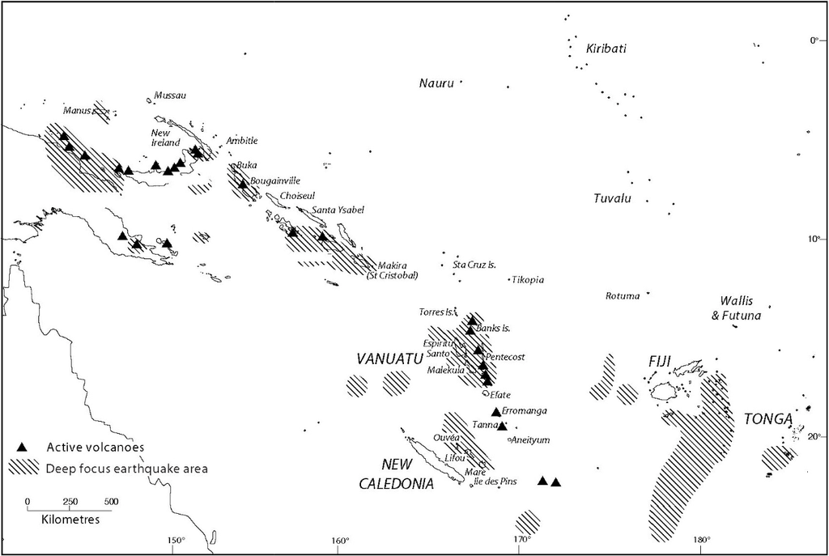

**Map 9:** Active volcanoes and earthquake areas in the south-west Pacific (after Brookfield and Hart_1971: 33)

The next reconstruction belongs to a set of formally similar items with meanings relating to bubbling, frothing and foaming (see *pura(q) on p.60). The semantic change evident between the Tolai and Mota glosses may perhaps be explained as transfer of meaning from ‘place/activity of emission’ to ‘matter emitted’.

| **POc** |  | *puro | ‘bubble up, boil, as hot spring’ |
| --- | --- | --- | --- |
| NNG | Kove | *pulou* | ‘come up, as a spring’ |
| PT | Molima | *pulo* | ‘bubbles’ |
| PT | Kilivila | *polu* | [V] ‘boil’ |
| MM | Tolai | *vuru* | ‘pumice, volvanic dust, lava’ |
| SES | Arosi | *huro-huro* | [V] ‘bubble, boil, be churned up’ |
| NCV | Mota | *vuro* | ‘volcanic vent, hot spring’ |

It is notable that in both cognate sets above, there is a tendency for the glosses to vary from one volcanic feature to another.

### 9.2. Earthquake

While the following two cognate sets are presumably related, we cannot unite them into a single set.

| **POc** |  | *drike-drike | ‘earthquake’ |
| --- | --- | --- | --- |
| Adm | Mussau | *ruke-ruke* | ‘earthquake’ |
| MM | Tinputz | *rik-rik* | ‘earthquake’; [V] ‘quake’ |

cf. also:

| PT | Molima | *(mʷa)niʔi-niʔi* | ‘earthquake’ |
| --- | --- | --- | --- |

| **POc** |  | *Rike | ‘earthquake’ |
| --- | --- | --- | --- |
| NNG | Manam | *rike* | ‘earthquake’ |
| NNG | Manam | *(mʷa)rike* | [N, V] ‘earthquake, quake’ |
| **PPn** |  | *mafu-ike | ‘earthquake’ (the etymology of mafu- is unknown) |
| Pn | Niuean | *mafuike* | ‘earthquake’ |
| Pn | Tongan | *mofuike* | ‘earthquake’ |
| Pn | Rennellese | *mahuike* | ‘deity who causes earthquakes’ |
| Pn | Samoan | *mafuiʔe* | ‘earthquake; deity from whom fire was obtained’ |
| Pn | East Futunan | *mafuike* | ‘earthquake’ |
| Pn | Māori | *mahuika* | ‘deity from whom fire was obtained by Maaui-tikitiki’ |

In several of the following cognate sets, the term for earthquake is closely related to the verb meaning ‘to shake’. Some form of onomatopoeic wordplay may explain the similarity of form between the various sets. For instance, Onin and Sekar, CEMP languages spoken in West New Guinea, both record *nuni* ‘earthquake’ while Yotafa on the north coast lists *nioni* ‘earthquake’ (Smits & Voorhoeve 1992:34).

| **PMP** |  | *ninih | ‘shake, tremble, rock’ (ACD) |
| --- | --- | --- | --- |
| **POc** |  | *[ni]nir | [V] ‘shake, quake’ |
| NNG | Gedaged | *nini* | ‘swing, oscillate, shake, rock’ |
| NNG | Mapos Buang | *(i-)nɛl* | ‘earthquake’ |
| NNG | Mumeng | *(zenag) nɛr* | ‘earthquake’ |
| MM | Patpatar | *ninir* | ‘shake, quake’ |
| Fij | Bauan | *nini* | ‘tremble, quake with fear or anger’ |
| Pn | Tongan | *nini-nini* | ‘shiver with cold’ |

In a number of northwest and southeast Solomons languages, the term for earthquake is nunu. PMP *uyuŋ ‘shake; earthquake’ would give POc *iu(ŋ). The actor pivot PMP form *ŋ-uyuŋ would give POc *ŋ-iu(ŋ). This may be ancestral to the form *niu* or *ñu* ‘to shake, hence ‘an earthquake’, found in two MM languages, Hoava and Roviana, as well as to *nunu* by regular depalatalisation.

| **PMP** |  | *uyuŋ | ‘shake; earthquake’ (ACD) |
| --- | --- | --- | --- |
| **POc** |  | *ŋ-iu(ŋ) | [V] ‘shake, quake’; [N] ‘earthquake’ |
| MM | Halia | *nun* | ‘earthquake’ |
| MM | Nduke | *nunu* | ‘earthquake’ |
| MM | Babatana | *nunu* | ‘earthquake’ |
| MM | Hoava | *niu* | ‘shake; earthquake’ |
| MM | Roviana | *niu* | ‘shake; earthquake’ |
| SES | ’Are’are | *nu-nunu* | ‘earthquake’ |
| SES | Sa’a | *nunu* | ‘earthquake’ |
| SES | Kwaio | *nunu* | ‘earthquake’ |

| **PSS** |  | *añu | [V] ‘shake’ |
| --- | --- | --- | --- |
| **PSS** |  | *añu-añu | [N] ‘earthquake’ |
| SES | Gela | *anu* | ‘shake’ |
| SES | Gela | *anu-anu* | ‘earthquake’ |
| SES | Bugotu | *añu* | ‘shake, of earthquake; earthquake’ |
| SES | Lau | *anu* | ‘shake, quake’ |
| SES | Lau | *anu-anu* | ‘earthquake’ |
| SES | Kwaio | *anu(leʔeni)* | ‘shake, jostle, knock down by shaking’ |
| SES | ’Are’are | *anu(i)* | ‘shake, move’ |
| SES | Sa’a | *enu, enu-enu* | ‘be loose, unstable’ |
| SES | Arosi | *anu(kaʔa)* | ‘tremble and go cold with fear’ |

| **PNCV** |  | *ruru | [V] ‘shake’; [N] ‘earthquake’ |
| --- | --- | --- | --- |
| NCV | Mota | *rir* | [V] ‘quake’; ‘earthquake’ |
| NCV | Raga | *ruru(i)* | ‘shake’ |
| NCV | Paamese | *(a)lū* | ‘earthquake’ |
| NCV | Nguna | *(na)ruru* | ‘earthquake’ |

### 9.3. Landslide

POc *solo was probably a verb, but its reflexes refer, inter alia, to landslides in several daughter languages. They are also found in Puluwatese (Mic), linked to star names, to refer to stars sinking towards the horizon (see Ch. 6, §5.4.2).

| **POc** |  | *solo | ‘sink down, subside; landslide’ |
| --- | --- | --- | --- |
| MM | Marovo | *(ta)ju-julu* | ‘landslide’ |
| MM | Babatana | *jolo* | ‘subside’ |
| SES | Lau | *to-toli(ŋi)* | ‘landslide’ |
| Mic | Woleaian | *toro* | ‘disappear, submerge, go out of sight, vanish’ |
| Mic | Marshallese | *tal* | ‘sink, submerge’ |
| Mic | Satawalese | *tol* | ‘disappear from sight’ |
| Fij | Rotuman | *solo* | ‘sink down’ |
| Pn | Niuean | *ho-holo* | ‘slip’ |
| Pn | Tongan | *holo* | ‘collapse, cave in’ |
| Pn | East Futunan | *solo* | ‘collapse, cave in; landslide’ |
| Pn | Samoan | *solo* | ‘slide, slip; landslide’ |
| Pn | Tikopia | *soro* | ‘rub, grate; landslide’ |
| Pn | Tahitian | *horo* | ‘landslide’ |
| Pn | Māori | *horo* | ‘landslide’ |
| Pn | Hawaiian | *holo* | ‘landslide’ |

| **PEOc** |  | *to(b,p)a | [VI] ‘(land) slip’ |
| --- | --- | --- | --- |
| **PEOc** |  | *ma-to(b,p)a | ‘landslip’ |
| SES | Gela | *matoba* | ‘landslip’ |
| SES | Bugotu | *matoba* | ‘landslip’ |
| SES | Longgu | *toba* | [VI] ‘(land) slip’ |
| SES | Arosi | *maoba* | ‘landslip’ |
| NCV | Raga | *matova* | ‘landslip, flood’ |
| NCV | Paamese | *matehe* | ‘landslide, slip’ |

### 9.4. Tidal wave

No POc term denoting tidal wave has been reconstructed. In contemporary languages, terms for tidal wave are compounds, with the first element often a reflex of *tasik ‘sea’ (Ch.4, §2.1) or *[u]Ruap ‘high tide’ (§2.6). These terms do not usually distinguish tsunamis, caused by undersea earth movements, from floods caused by a combination of high tide and strong wind. In any case, catastrophic tidal waves probably occur only once or twice a century, and affect only localised places. Although a number of terms for ‘tidal wave’ have been collected, and are listed below, cognates exist only within low level subgroups.

| Adm | Mussau | *manu gagaga* | ‘tidal wave’ (*manu* ‘water’) |
| --- | --- | --- | --- |
| Adm | Lou | *ultum* | ‘tidal wave’ |
| MM | Nakanai | *karoro* | ‘tidal wave’ |
| MM | Tolai | *roro* | ‘tidal wave’ |
| MM | Ramoaaina | *tai-gugu* | ‘tidal wave’ (*tai* ‘sea’) |
| SES | Gela | *gogo* | ‘tidal wave’ |
| SES | Gela | *lua-lua* | ‘flood, tidal wave’ (*lua* ‘full tide’) |
| SES | Bugotu | *gogovi* | ‘tidal wave’ |
| SES | Arosi | *rua-rua* | ‘flood of water’ |
| SES | Arosi | *asi-ora* | ‘tidal wave’ (*ora* ‘possessed by foul ghost’) |
| NCV | Tamambo | *tasi wala-walau* | ‘tidal wave’ (*walau* ‘to run’) |
| Fij | Bauan | *ua tale-tale* | ‘tidal wave’ (*ua* ‘tide, wave’, *tale-tale* ‘repeated backwash of waves’) |
| Fij | Bauan | *ua loka* | ‘tidal wave’ (*ua* ‘tide, wave’, *loka* ‘very heavy breakers or high tides that flow inland’) |
| Pn | Tongan | *peau kula* | ‘tidal wave’ (lit. ‘wave red’) |
| Pn | Niuean | *peau afi* | ‘tidal wave’ (lit. ‘wave fire’) |
| Pn | Hawaiian | *kai hōʔeʔe* | ‘tidal wave’ |

### 9.5. Flood, submerging tide

A PMP term for ‘flood’ (V and N) is continued in two known Oceanic witnesses. In Sa’a its reflex is a noun referring to a high spring tide. In Tongan it is a verb denoting the state or process of a river being in flood.

| **PMP** |  | *bahaq | ‘a flood; overflow, be in flood’ (ACD; Dempwolff 1938) |
| --- | --- | --- | --- |
| **POc** |  | *pa(a)q | ‘overflow, flood’ (ACD) |
| SES | Sa’a | *(lua) hā* | ‘high spring tide’ |
| Pn | Tongan | *fā* | ‘(of a river) to overflow, be in flood’ |

As a compound with the term for fresh water, POc *waiR pa(a)q ‘river floodwaters’, is traceable back to PMP, although the Tongan form is our only Oceanic reflex.

| **PMP** |  | *wahir bahaq | ‘floodwaters’ (ACD) |
| --- | --- | --- | --- |
| **POc** |  | *waiR pa(a)q | ‘river floodwaters’ |
| Pn | Tongan | *vai fā* | ‘flood (from a river), river in flood’ |

Flooding for coastal dwellers on small Oceanic islands is likely to be the result of an unusually high tide (POc *[u]Ruap ‘high tide; to flow in of tide’, see Ch.4, §2.6), rather than heavy rain. King tides or spring tides are phenomena which occur at regular intervals, so are unlikely to be of more than nuisance value except when exacerbated by high winds. Terms for tidal flooding may be compounds including reflexes of *[u]Ruap, or a related form (*[ma-]uRua(p) ‘flood, be flooded’) (Sa’a *lua hā* ‘high spring tide’, Mota *rue lava* ‘large tide’, Bauan Fijian *ua luvu* ‘submerging tide’). Other POc terms include reflexes of *lolo (V) ‘flood’, and *lomak (N,V) ‘flood, of sea’.

| **POc** |  | *[ma-]uRua(p) | ‘flood, be flooded’ |
| --- | --- | --- | --- |
| NNG | Manam | *urua* | ‘flood, torrent’ |
| PT | Molima | *moluva* | ‘flood’ |
| PT | Dobu | *muluwa* | ‘flood’ |
| NCV | Tamambo | *moruae* | ‘flood, big river’ |

| **PMP** |  | *lebleb | [V] ‘flood’ |
| --- | --- | --- | --- |
| **POc** |  | *lolo | [V] ‘flood’ |
| Adm | Andra | *lolo(mat)* | ‘windward part of reef flat, covered at high tide’ |
| NNG | Gedaged | *lolo(ani)* | [V] ‘inundate, flood, drown, stream over, flow over, cause to sink under water’ |
| Fij | Bauan | *lolo* | ‘beginning to rise, of the tide’ |
| Pn | Samoan | *lolo* | [V] ‘overflow’; [N] ‘flood’ |

| **POc** |  | *lomak | [N,V] ‘flood, of sea’ |
| --- | --- | --- | --- |
| NNG | Takia | *lom* | ‘flood’ |
| NNG | Gedaged | *lom, lom-lom* | ‘the dirty water that flows off after rain, the water that lies around after rain’ |
| MM | Sursurunga | *lom-lom* | ‘high tide, flood’ |
| **PPn** |  | *lo(o)ma, *lo(o)maki | ‘flood caused by high seas or tides’ (Biggs and Clark 1993) |
| Pn | Tongan | *lōmaki* | [N] ‘flood, deluge’ |
| Pn | East Futunan | *lōmaki* | ‘flooded as by large waves’ |
| Pn | West Uvean | *lo-loma* | ‘sea flood, tide’ |
| Pn | Māori | *roma* | ‘flood, flood tide, stream, current’ |
| Pn | Tuamotuan | *roma* | ‘flood’ |

The reconstruction below appears to have referred to flooding or gushing.

| **POc** |  | *ñoro | ‘flood, gush, flow everywhere’ (Blust 1998b) |
| --- | --- | --- | --- |
| Adm | Lou | *noro* | ‘flood’ |
| NNG | Mangap | *no-nor* | ‘tidal wave, flood’ |
| MM | Halia | *nolo* | ‘flood’ |
| MM | Tolai | *noro* | ‘to pour forth, gush, flow quickly’ |
| SV | Anejom̃ | *ya* | ‘flow everywhere, out of control’ |

### 9.6. Storm, hurricane

Terms for destructive winds and storms are treated in Chapter 5. They include POc *paRiu ‘cyclone’ (from PAn *baRiuS ‘typhoon’), POc *mal(i,e)u ‘wind’ which gives rise to PMic *malu-malu ‘storm, typhoon’ and POc *apaRat ‘wet season when northwesterlies blow and sea is rough’ from which come PCP *avā ‘storm’, PPn *afā ‘storm, hurricane’.

### 9.7. Whirlpools, waterspouts, whirlwinds

Whirlpools and waterspouts and some other phenomena such as rainbows and echoes, are regarded in many Austronesian-speaking communities as supernatural occurrences, and are sometimes treated as a natural category, ‘taboo thing’ or similar. Accordingly we sometimes find ‘rainbow’ and ‘whirlwind’ within the same cognate set, or even, as in Mortlockese (Mic) *awúniyar* ‘whirlwind, tornado, rainbow’, referred to by the same word.

The meanings of the prefix *qā-, and the alternative form *pua- (blowing?) in the following set are uncertain.

| **PEOc** |  | *siosio | ‘(?) whirlwind, rainbow’ |
| --- | --- | --- | --- |
| NCV | Mota | *ga-siosio* | ‘rainbow’ (see note above) |
| **PPn** |  | *qā-siosio | ‘whirlwind, waterspout’ |
| Pn | Niuean | *hio-hio* | ‘whirlwind, tornado’ (from McEwen. Sperlich gives *tiotio*.) |
| Pn | Tongan | *ʔa-hiohio* | ‘whirlwind’ |
| Pn | East Futunan | *ʔā-siosio* | ‘waterspout’ |
| Pn | Samoan | *ā-siosio* | ‘whirlwind’ |
| Pn | Tokelauan | *ā-hiohio* | ‘whirlwind, waterspout’ |
| Pn | Rarotongan | *puā-ʔioʔio* | ‘whirlwind’ |
| Pn | Tahitian | *pua-hiohio* | ‘whirlwind, cyclone’ |
| Pn | Māori | *ā-fiofio* | ‘whirlwind’ |
| Pn | Hawaiian | *pua-hiohio* | ‘whirlwind’ |

The next item may be associated in some way with POc *piro ‘twist together’ (vol.1,287).

| **POc** |  | *piru-piru | ‘whirlwind, waterspout’ |
| --- | --- | --- | --- |
| NNG | Kove | *vili-viliu* | ‘small whirlwind’ |
| PT | Kilivila | *vi-vilu(wa)* | ‘whirlwind, waterspout’ |
| PT | Wedau | *viri-viri(toto)* | ‘whirlwind, waterspout’ |
| MM | Roviana | *vi-viru(a)* | ‘waterspout’ |
| SES | Ghari | *viru* | ‘waterspout’ |
| **PEOc** |  | *libo | ‘eddy, whirlpool’ |
| SES | Kwaio | *libo* | ‘eddy in stream, whirlpool’ |
| Pn | Niuean | *lipo, lipo-lipo* | ‘ripples’ (not incl. in Sperlich) |
| Pn | Tikopia | *(mā)ripo-ripo* | ‘whirl’ |
| Pn | Tahitian | *ripo-ripo* | ‘wavelets in a ring’ |
| Pn | Māori | *ripo* | ‘eddy, whirlpool’ |

## 10. Conclusion

Proto Oceanic terms are readily reconstructable for a number of landscape features, including land, island, beach, sandy ground, cape, bay, river, mountain, inland mountain country, valley, flat land, bushland, cultivated land, fallow land, lake, swampy ground, rock, and sand. Other reconstructable terms refer to fresh water sources and to the productive or unproductive nature of the land, both matters of crucial importance to human settlement. There are POc reconstructions for mineral substances, including obsidian and other stone, sand and gravel, coral and lime, pumice, earth, salt and clay. Although obsidian is found only in a few widely scattered locations, and clay suitable for potmaking is also limited in its range, both were sought-after items, and archaeological evidence indicates that POc speakers would have been familiar with either the raw material or its manufactured form through well-established trade networks.

But there are salient parts of Oceanic land environments for which we cannot reconstruct a POc term (and often no PWOc or PEOc term either). Reconstructions for features associated with volcanic action, such as hot springs and ash are tentative, based on apparent reflexes which vary quite widely in meaning. There are reconstructions for ‘earthquake’ and ‘flood’, but not for ‘tidal wave’. What does this tell us? Probably not that POc lacked these terms, but that they have been lost, or are not widely enough reflected for us to be able to identify them as POc. It may be that POc had compound terms for certain of these concepts, and it seems that compounds are less stable than simple lexemes.

## Notes

[^1]: Thanks are due to Ann Chowning, Ralph Lawton, John Lynch, Françoise Ozanne-Rivierre and Ian Scales who have all made useful suggestions and contributed additional data to this chapter.
[^2]: The form POc *tano(q) given in vol.1,119 has now been revised to *tanoq. Evidence supporting final *-q lies in the retention of a final vowel in Kwamera (John Lynch, pers. comm.) and Iaai (Françoise Ozanne-Rivierre, pers. comm.) .
[^3]: In vol.1,189 the form POc *ijuŋ ‘projecting headboard of prow’ is erroneously given for *(i,u)cuŋ. This is almost certainly the same etymon as that reconstructed here.
[^4]: It is tempting to decide that this is the same term as POc *koro ‘(i) any fenced-in area’, (ii) settlement fortified by a palisade or ditch’ (Pawley 2005), on the basis that fortifications were typically situated on high ground. But there is strong evidence that there were two distinct terms at least as far back as POc.
[^5]: Languages where kinds of swamp are lexically distinguished include Kiriwina *dumia* ‘inland swamp’, *pasa*, *vamova* ‘mangrove swamp’ and Kwaio *kunu*, *kū-kunu* ‘saltwater mud’, *kunu-kunu* ‘freshwater mud, swamp’. Also Ulawa *lo-lolo* ‘swamp in which sago palms grow’ and closely related language Sa’a which has *lo-loŋo* ‘mangrove swamp’.
[^6]: In vol.1,139 the form PCP *pusi is erroneously given for *vusi (POc *p split into PCP *p and *v).